# Математика — Итоговое домашнее задание

# А. Д. Егоров

```python
import numpy as np
from scipy import stats
import pandas as pd

from sklearn.preprocessing import (
    OneHotEncoder,
    StandardScaler,
)

import matplotlib.pyplot as plt
import seaborn as sns

# Подгрузим полезные функции
from utils import *

# USE THIS STYLE
# plt.style.use('https://github.com/dhaitz/matplotlib-stylesheets/raw/master/pitayasmoothie-light.mplstyle')
#
# OR THIS STYLE
import aquarel

theme = aquarel.load_theme("arctic_light")
theme.set_font(family="serif")
theme.apply()

# Сделаем автоподгрузку всех изменений при перепрогонке ячейки
# %load_ext autoreload
# %autoreload 2

%matplotlib inline
```

```python
custom_pallete = {
    "red": "#BF616A",
    "orange": "#D08770",
    "yellow": "#EBCB8B",
    "green": "#A3BE8C",
    "purple": "#B48EAD",

    "light_green": "#8FBCBB",
    "light_gray_blue": "#88C0D0",
    "light_blue": "#81A1C1",
    "blue": "#5E81AC",

    "dark_black_blue": "#2E3440",
    "dark_gray_blue": "#3B4252",
    "dark_gray_green": "#434C5E",
    "gray": "#4C566A",

    "light_gray": "#d8dee9",
    "white": "#e5e9f0",
    "snow_white": "#eceff4",
}
```

## Импортируем данные

```python
df = pd.read_csv("../data/processed/cars_train_processed.csv")

df.head()
```

|  | name | year | selling_price | km_driven | fuel | seller_type | transmission | owner | mileage | engine | max_power | seats | brand | max_torque | max_torque_rpm |
| --- | --- | --- | --- | --- | --- | --- | --- | --- | --- | --- | --- | --- | --- | --- | --- |
| 0 | Maruti Swift Dzire VDI | 2014 | 450000 | 145500 | Diesel | Individual | Manual | First Owner | 23.40 | 1248 | 74.00 | 5 | Maruti | 190 | 2000 |
| 1 | Skoda Rapid 1.5 TDI Ambition | 2014 | 370000 | 120000 | Diesel | Individual | Manual | Second Owner | 21.14 | 1498 | 103.52 | 5 | Skoda | 250 | 2500 |
| 2 | Hyundai i20 Sportz Diesel | 2010 | 225000 | 127000 | Diesel | Individual | Manual | First Owner | 23.00 | 1396 | 90.00 | 5 | Hyundai | 220 | 2750 |
| 3 | Maruti Swift VXI BSIII | 2007 | 130000 | 120000 | Petrol | Individual | Manual | First Owner | 16.10 | 1298 | 88.20 | 5 | Maruti | 113 | 4500 |
| 4 | Hyundai Xcent 1.2 VTVT E Plus | 2017 | 440000 | 45000 | Petrol | Individual | Manual | First Owner | 20.14 | 1197 | 81.86 | 5 | Hyundai | 114 | 4000 |

# Введение

Дан датасет с параметрами автомобилей (год сборки, пробег, хар-ки двигаделя, кол-во владельцев и др.). Требуется определить цену автомобиля основываясь на приведенных данных (построить регрессионную модель методом МНК и выделить основные фитчи для нее).

# EDA

### Посмотрим на общую информацию по численным данным из таблицы

```python
df.describe()
```

|  | year | selling_price | km_driven | mileage | engine | max_power | seats | max_torque | max_torque_rpm |
| --- | --- | --- | --- | --- | --- | --- | --- | --- | --- |
| count | 5820.000000 | 5.820000e+03 | 5.820000e+03 | 5820.000000 | 5820.000000 | 5820.000000 | 5820.000000 | 5820.000000 | 5820.000000 |
| mean | 2013.646220 | 5.297361e+05 | 7.320612e+04 | 19.479352 | 1431.332131 | 87.862680 | 5.437457 | 175.179725 | 3042.085567 |
| std | 3.885997 | 5.311637e+05 | 6.005462e+04 | 4.049110 | 491.438766 | 31.911631 | 0.991477 | 108.012813 | 891.540801 |
| min | 1994.000000 | 2.999900e+04 | 1.000000e+00 | 0.000000 | 624.000000 | 32.800000 | 2.000000 | 47.000000 | 1400.000000 |
| 25% | 2011.000000 | 2.500000e+05 | 3.669725e+04 | 16.800000 | 1197.000000 | 67.100000 | 5.000000 | 112.000000 | 2250.000000 |
| 50% | 2014.000000 | 4.200000e+05 | 6.800000e+04 | 19.440000 | 1248.000000 | 81.830000 | 5.000000 | 160.000000 | 3000.000000 |
| 75% | 2017.000000 | 6.500000e+05 | 1.000000e+05 | 22.540000 | 1498.000000 | 100.000000 | 5.000000 | 200.000000 | 4000.000000 |
| max | 2020.000000 | 1.000000e+07 | 2.360457e+06 | 42.000000 | 3604.000000 | 400.000000 | 14.000000 | 1863.000000 | 5300.000000 |

### Посмотрим на распределение некоторых показателей

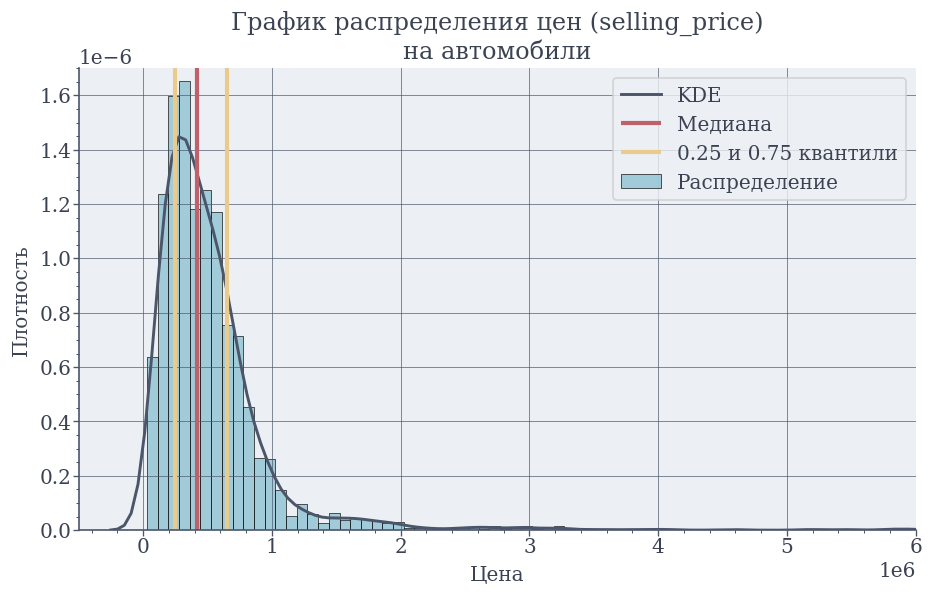

```python
selling_price_description = df.selling_price.describe(include="all")

plot_info = {
    "title": "График распределения цен (selling_price)\nна автомобили",
    "xlabel": "Цена",
    "ylabel": "Плотность",
}

fig, ax = plt.subplots(figsize=(9, 5), dpi=120)

sns.histplot(
    df["selling_price"],
    bins=120,
    ax=ax,
    stat="density",
    label="Распределение",
    color=custom_pallete["light_gray_blue"],
)

sns.kdeplot(
    df["selling_price"],
    color=custom_pallete["gray"],
    ax=ax,
    label="KDE",
)

ax.vlines(
    x=selling_price_description["50%"],
    ymax=2e-6,
    ymin=0,
    colors=custom_pallete["red"],
    linewidth=2.5,
    label="Медиана",
)

ax.vlines(
    x=(
        selling_price_description["25%"],
        selling_price_description["75%"],
    ),
    ymax=2e-6,
    ymin=0,
    colors=custom_pallete["yellow"],
    linewidth=2.5,
    label="0.25 и 0.75 квантили",
)

ax.set_xlim([-0.05e7, 0.6e7])
ax.set_ylim([0., 1.7e-6])
ax.set_title(plot_info["title"])
ax.set_xlabel(plot_info["xlabel"])
ax.set_ylabel(plot_info["ylabel"])
ax.legend()

plt.show()
```

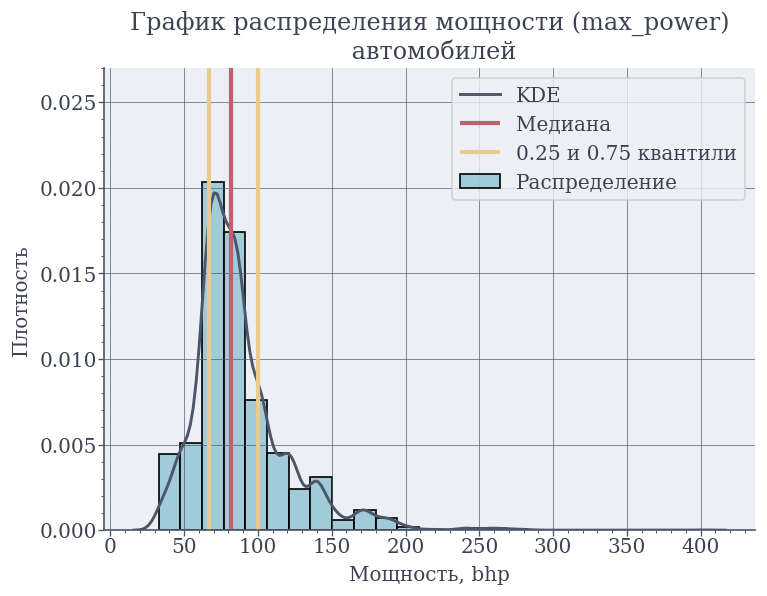

```python
max_power_description = df.max_power.describe(include="all")

plot_info = {
    "title": "График распределения мощности (max_power)\n автомобилей",
    "xlabel": "Мощность, bhp",
    "ylabel": "Плотность",
}

fig, ax = plt.subplots(figsize=(7, 5), dpi=120)

sns.histplot(
    df["max_power"],
    bins=25,
    ax=ax,
    stat="density",
    label="Распределение",
    color=custom_pallete["light_gray_blue"],
)

sns.kdeplot(
    df["max_power"],
    ax=ax,
    label="KDE",
    color=custom_pallete["gray"],
)

ax.vlines(
    x=max_power_description["50%"],
    ymax=3e-2,
    ymin=0,
    colors=custom_pallete["red"],
    linewidth=2.5,
    label="Медиана",
)

ax.vlines(
    x=(
        max_power_description["25%"],
        max_power_description["75%"],
    ),
    ymax=3e-2,
    ymin=0,
    colors=custom_pallete["yellow"],
    linewidth=2.5,
    label="0.25 и 0.75 квантили",
)

ax.set_ylim([0., 2.7e-2])

ax.set_title(plot_info["title"])
ax.set_xlabel(plot_info["xlabel"])
ax.set_ylabel(plot_info["ylabel"])


plt.legend()
plt.show()
```

```python
max_power_description
```

```
count    5820.000000
mean       87.862680
std        31.911631
min        32.800000
25%        67.100000
50%        81.830000
75%       100.000000
max       400.000000
Name: max_power, dtype: float64
```

В выборке присутствуют машины разных мощностей. Есть как маломощные авто, так и с большим количеством лошадиных сил. Но в основном цена на автомобль находится в промежутке от 67 bhp до 100 bhp.

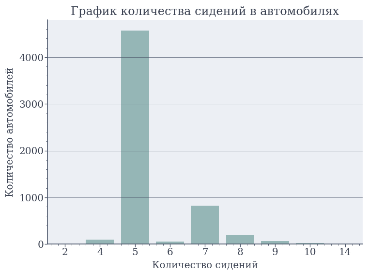

```python
plot_info = {
    "title": "График количества сидений в автомобилях",
    "xlabel": "Количество сидений",
    "ylabel": "Количество автомобилей",
}

fig, ax = plt.subplots(figsize=(7,5), dpi=120)

sns.barplot(
    x=df["seats"].value_counts().index,
    y=df["seats"].value_counts(),
    ax=ax,
)


ax.set_title(plot_info["title"])
ax.set_xlabel(plot_info["xlabel"])
ax.set_ylabel(plot_info["ylabel"])


plt.show()
```

Больше всего на рынке автомобилей с 5 сиденьями (стандартное количество). Присутствуют так же авто с 14 сиденьями, возможно микроавтобус.

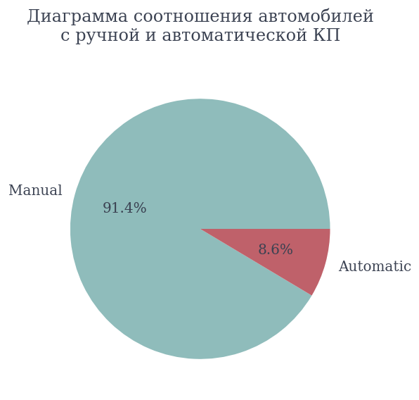

```python
fig, ax = plt.subplots(figsize=(7,5), dpi=120)

ax.pie(
    x=df["transmission"].value_counts(),
    labels=df["transmission"].value_counts().index,
    autopct='%1.1f%%',
)

title = """Диаграмма соотношения автомобилей
с ручной и автоматической КП
"""
ax.set_title(title)

plt.show()
```

Больше всего в продаже автомобилей с ручной коробкой передач. Видимо рынок располагается в месте, где автоматическая коробка передач - очень дорогая опция.

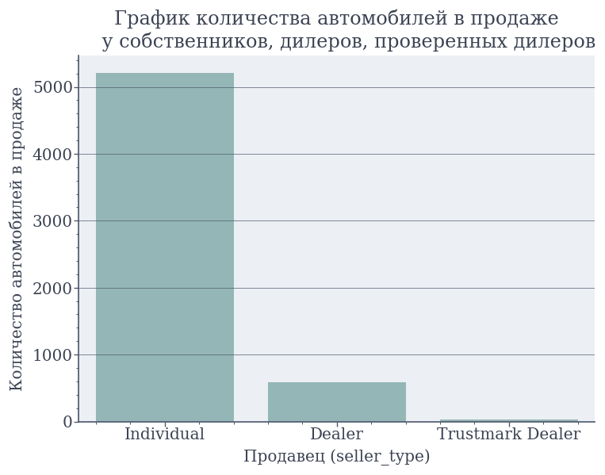

```python
plot_info = {
    "title": """График количества автомобилей в продаже
    у собственников, дилеров, проверенных дилеров""",
    "xlabel": "Продавец (seller_type)",
    "ylabel": "Количество автомобилей в продаже",
}


fig, ax = plt.subplots(figsize=(7,5), dpi=120)

sns.barplot(
    x=df["seller_type"].value_counts().index,
    y=df["seller_type"].value_counts(),
    ax=ax
)


ax.set_title(plot_info["title"])
ax.set_xlabel(plot_info["xlabel"])
ax.set_ylabel(plot_info["ylabel"])


plt.show()
```

Больше всего частных продавцов. Оно не удивительно, ведь чтобы сдать машину дилеру, она должна соответствовать должному уровню (быть в более чем приемлемом состоянии).

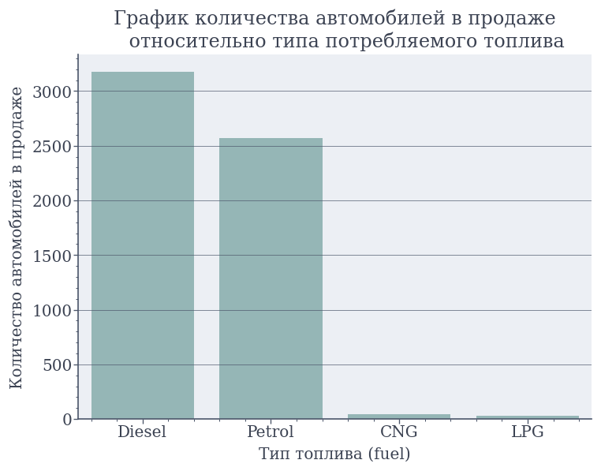

```python
plot_info = {
    "title": """График количества автомобилей в продаже
    относительно типа потребляемого топлива""",
    "xlabel": "Тип топлива (fuel)",
    "ylabel": "Количество автомобилей в продаже",
}

fig, ax = plt.subplots(figsize=(7,5), dpi=120)

sns.barplot(
    x=df["fuel"].value_counts().index,
    y=df["fuel"].value_counts(),
    ax=ax
)

ax.set_title(plot_info["title"])
ax.set_xlabel(plot_info["xlabel"])
ax.set_ylabel(plot_info["ylabel"])

plt.show()
```

Ожитаемое распределение, в основном машины поставляются с дизельным или бензиновым двигателем, остальное - редкость.

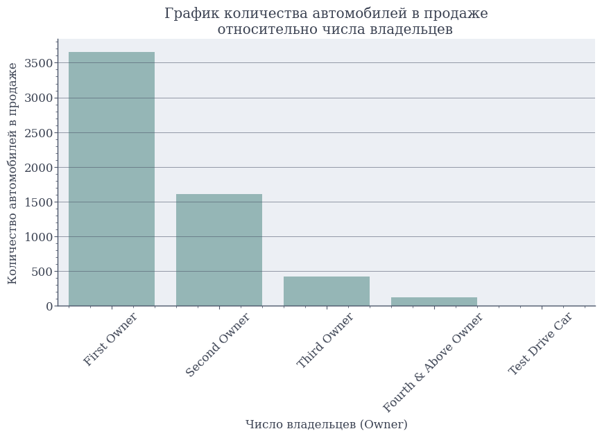

```python
plot_info = {
    "title": """График количества автомобилей в продаже
    относительно числа владельцев""",
    "xlabel": "Число владельцев (Owner)",
    "ylabel": "Количество автомобилей в продаже",
}

fig, ax = plt.subplots(figsize=(10,5), dpi=100)

sns.barplot(
    x=df["owner"].value_counts().index,
    y=df["owner"].value_counts(),
    ax=ax
)

ax.axes.set_xticklabels(df["owner"].value_counts().index, rotation=45)

ax.set_title(plot_info["title"])
ax.set_xlabel(plot_info["xlabel"])
ax.set_ylabel(plot_info["ylabel"])

plt.show()
```

Больше всего продается автомобилей после первого владельца. Очень мало автомобилей только что сошедших с тестдрайва.

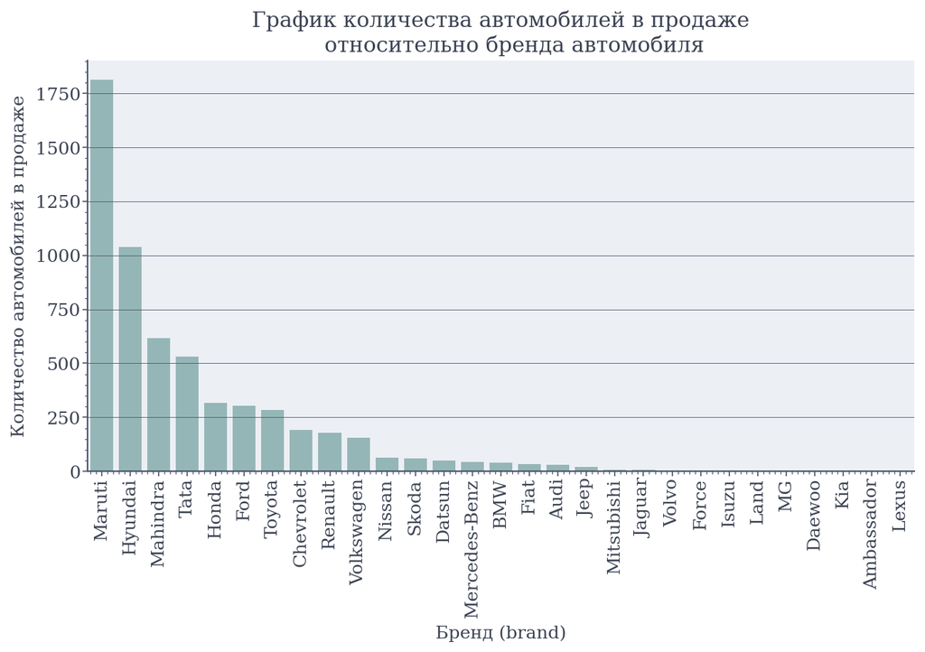

```python
plot_info = {
    "title": """График количества автомобилей в продаже
    относительно бренда автомобиля""",
    "xlabel": "Бренд (brand)",
    "ylabel": "Количество автомобилей в продаже",
}

fig, ax = plt.subplots(figsize=(10,5), dpi=150)

sns.barplot(
    x=df["brand"].value_counts().index,
    y=df["brand"].value_counts(),
    ax=ax
)

ax.axes.set_xticklabels(df["brand"].value_counts().index, rotation=90)

ax.set_title(plot_info["title"])
ax.set_xlabel(plot_info["xlabel"])
ax.set_ylabel(plot_info["ylabel"])

plt.show()
```

Больше всего на рынке присутствует японских автомобилей. Скорее всего рынок авто расположен либо в Японии, либо в азиатской части Евразии.

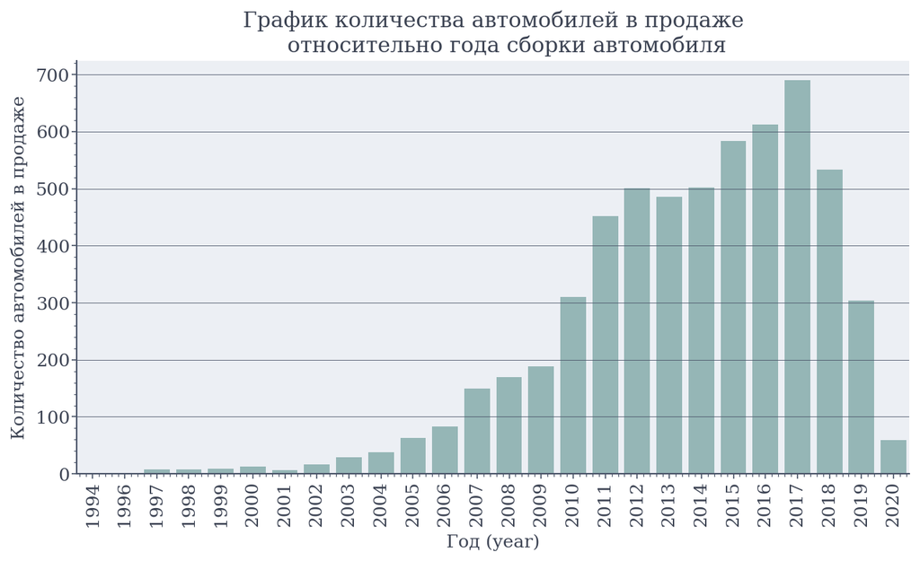

```python
plot_info = {
    "title": """График количества автомобилей в продаже
    относительно года сборки автомобиля""",
    "xlabel": "Год (year)",
    "ylabel": "Количество автомобилей в продаже",
}

fig, ax = plt.subplots(figsize=(10,5), dpi=150)

sns.barplot(
    x=df["year"].value_counts().sort_index().index,
    y=df["year"].value_counts().sort_index().values,
    ax=ax,
)

ax.axes.set_xticklabels(df["year"].value_counts().sort_index().index, rotation=90)

ax.set_title(plot_info["title"])
ax.set_xlabel(plot_info["xlabel"])
ax.set_ylabel(plot_info["ylabel"])

plt.show()
```

Основную часть рынка заполняют относительно свежие автомобили (автомобили, которым меньше 10 лет).

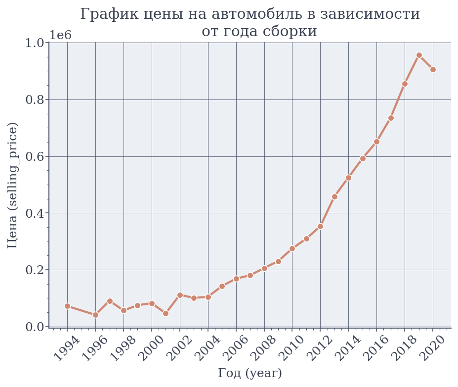

```python
mean_price_year = []

for i in range(df["year"].min(), df["year"].max() + 1):
    mean_price_year.append(df[df["year"] == i]["selling_price"].mean())

plot_info = {
    "title": """График цены на автомобиль в зависимости
    от года сборки""",
    "xlabel": "Год (year)",
    "ylabel": "Цена (selling_price)",
}

fig, ax = plt.subplots(figsize=(7, 5), dpi=150)

sns.lineplot(
    x=list(range(1994, 2021)),
    y=mean_price_year,
    ax=ax,
    linewidth=2,
    marker="o",
    color=custom_pallete["orange"]
)

ax.axes.set_xticks(list(range(1994, 2021, 2)))
ax.axes.set_xticklabels(list(range(1994, 2021, 2)), rotation=45)
ax.set_title(plot_info["title"])
ax.set_xlabel(plot_info["xlabel"])
ax.set_ylabel(plot_info["ylabel"])

plt.show()
```

В среднем цена за автомобиль относительно его года сборки растет. Свежие автомобили всегда в цене.

## Теория вероятностей и мат. статистика

Выборку можно разбить на сегменты по следующим фитчам:

- тип КП
- год сборки автомобиля
- количество владельцев (1, 2, 3, 4 и более)
- бренд
- пробег
- мощьность
- тип топлива
- продавец

Отноительно них и будем строить гипотезы.

### Распределение цен на автомобили с ручной КП совпадает с распределением цен на автомобили с автоматической КП с точностью до смещения

```python
test = stats.mannwhitneyu(
    df[df.transmission == "Manual"]["selling_price"],
    df[df.transmission == "Automatic"]["selling_price"],
    alternative="two-sided",
)
pd.DataFrame([["Manual vs Automatic", test.statistic, test.pvalue]], columns=["transmission", "MW_statistic", "MW_pvalue"])
```

|  | transmission | MW_statistic | MW_pvalue |
| --- | --- | --- | --- |
| 0 | Manual vs Automatic | 471101.5 | 1.975662e-125 |

Полученное $pvalue < 0.05$, следовательно, распределения не одинаковы.

Посмотрим может на KDEplot и после попробуем провести тест со смещением:

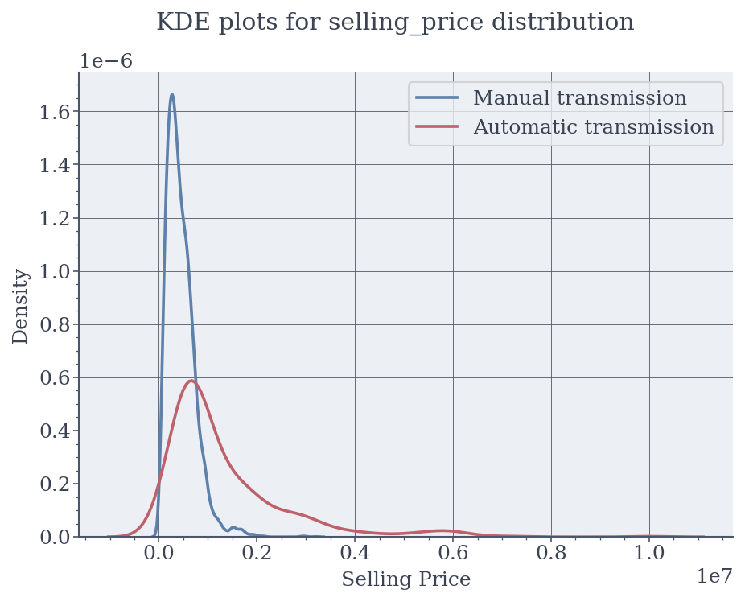

```python
fig, ax = plt.subplots(figsize=(7, 5), dpi=150)


sns.kdeplot(
    df[df.transmission == "Manual"]["selling_price"],
    color=custom_pallete["blue"],
    label="Manual transmission",
    ax=ax,
)
sns.kdeplot(
    df[df.transmission == "Automatic"]["selling_price"],
    color=custom_pallete["red"],
    label="Automatic transmission",
    ax=ax,
)

ax.set_xlabel("Selling Price")

fig.suptitle("KDE plots for selling_price distribution")
plt.legend()
plt.show()
```

Найдем смещение

```python
shift = (
    df[df.transmission == "Manual"]["selling_price"].median()
    - df[df.transmission == "Automatic"]["selling_price"].median()
)
shift
```

```
-450000.0
```

Еще раз проведем тест

```python
test = stats.mannwhitneyu(
    df[df.transmission == "Manual"]["selling_price"] - shift,
    df[df.transmission == "Automatic"]["selling_price"],
    alternative="two-sided"
)
pd.DataFrame([["Manual vs Automatic", test.statistic, test.pvalue]], columns=["transmission", "MW_statistic", "MW_pvalue"])
```

|  | transmission | MW_statistic | MW_pvalue |
| --- | --- | --- | --- |
| 0 | Manual vs Automatic | 1291985.5 | 0.354551 |

При должном смещении тест Манна-Уитни выполняется ($pvalue > 0.05$), следовательно, выдвинутая гипотеза принимается.

Тест Манна-Уитни можно интерпретировать как тест, показывающий разницу в медианах. Построим для медиан точечные и интервальные оценки (Эфронов доверительный интервал):

```python
manual_SP_median = []
automatic_SP_median = []

X_m = df[df.transmission == "Manual"]["selling_price"]
X_a = df[df.transmission == "Automatic"]["selling_price"]

for _ in range(X_m.shape[0]):
    manual_SP_median.append(
        np.median(
            np.random.choice(
                X_m,
                X_m.shape[0],
                replace=True,
            )
        )
    )

for _ in range(X_a.shape[0]):
    automatic_SP_median.append(
        np.median(
            np.random.choice(
                X_a,
                X_a.shape[0],
                replace=True,
            )
        )
    )

pd.DataFrame(
    [
        [
            "Manual",
            round(np.mean(manual_SP_median), 2),
            [round(x, 2) for x in np.percentile(manual_SP_median, q=[2.5, 97.5])],
        ],
        [
            "Automatic",
            round(np.mean(automatic_SP_median), 2),
            [round(x, 2) for x in np.percentile(automatic_SP_median, q=[2.5, 97.5])],
        ],
    ],
    columns=[
        "Transmission type",
        "SP median estim",
        "Conf int for SP median"
    ],
)
```

|  | Transmission type | SP median estim | Conf int for SP median |
| --- | --- | --- | --- |
| 0 | Manual | 398218.62 | [390000.0, 400000.0] |
| 1 | Automatic | 846810.18 | [775000.0, 925000.0] |

SP - selling price

Получилось так, что медиана цен на автомобиль с ручной коробкой передач в среднем меньше, чем для автомобилей с автоматической КП. Это логично, т.к. автоматическая КП - более новое техническое решение, дающее боше удобств в пользовании автомобилем. Цена на автомобиль с ручной КП будет выше, только если это какой-либо гоночный, ралийный или колекционный автомобиль, либо если автоматическая КП для аналогичной версии автомобиля менее надежная и недолговечная.

### Побег (`km_driven`) для машин, бывших во владении у одного и двух человек, в среднем одинаковый

> Хочется проверить эту гипотезу, т.к. зачастую машины с лучшим состоянием - это машины бывшие во владении у меньшего количества людей и с меньшим пробегом, и кажется, что разницы в пробеге для одного и двух владельца либо не должно быть, либо она минимальна.

Проверим гипотезу тестом Стьюдента

```python
test = stats.ttest_ind(
    df[df["owner"] == "First Owner"]["km_driven"],
    df[df["owner"] == "Second Owner"]["km_driven"],
)
pd.DataFrame(
    [["First vs Second", test.statistic, test.pvalue]],
    columns=["Owner", "ttest_statistic", "ttest_pvalue"],
)
```

|  | Owner | ttest_statistic | ttest_pvalue |
| --- | --- | --- | --- |
| 0 | First vs Second | -16.898042 | 2.000188e-62 |

$pvalue < 0.05$, следовательно, гипотеза отклоняется.

Выполним смещение и прогоним тест еще раз

```python
shift = df[df["owner"] == "First Owner"]["km_driven"].mean() - df[df["owner"] == "Second Owner"]["km_driven"].mean()
shift
```

```
-29635.156599190894
```

```python
test = stats.ttest_ind(
    df[df["owner"] == "First Owner"]["km_driven"] - shift,
    df[df["owner"] == "Second Owner"]["km_driven"],
)
pd.DataFrame([["First vs Second", test.statistic, test.pvalue]], columns=["Owners", "ttest_statistic", "ttest_pvalue"])
```

|  | Owners | ttest_statistic | ttest_pvalue |
| --- | --- | --- | --- |
| 0 | First vs Second | 8.297539e-15 | 1.0 |

$pvalue > 0.05$, следовательно, тест Стьюдента пройден. Можно сказать, что пробег на автомобилях с одним в среднем на 29.6 тыс. км меньше, чем на автомобилях с двумя владельцами.

```python
def t_conf_int(alpha, X):
    """
    Точный доверительный интервал
    """

    mu_hat = np.mean(X)
    var_hat = np.var(X)
    n = len(X)

    t_rv = stats.t(df=n - 1)
    t_crit = t_rv.ppf(1 - alpha / 2)

    left = mu_hat - t_crit * np.sqrt(var_hat / n)
    right = mu_hat + t_crit * np.sqrt(var_hat / n)

    return left, right
```

Построим точные доверительные интервалы для пробега на автомобиле, бывшем во владении у одного и двух человек:

```python
# first owner km driven
F_owner_km = df[df["owner"] == "First Owner"]["km_driven"]
# second owner km driven
S_owner_km = df[df["owner"] == "Second Owner"]["km_driven"]


pd.DataFrame(
    [
        [
            "First",
            round(np.mean(F_owner_km), 2),
            [round(x, 2) for x in t_conf_int(0.05, F_owner_km)],
        ],
        [
            "Second",
            round(np.mean(S_owner_km), 2),
            [round(x, 2) for x in t_conf_int(0.05, S_owner_km)],
        ],
    ],
    columns=[
        "Owner",
        "km_driven mean",
        "Conf int for km_driven"
    ],
)
```

|  | Owner | km_driven mean | Conf int for km_driven |
| --- | --- | --- | --- |
| 0 | First | 61022.76 | [59405.06, 62640.46] |
| 1 | Second | 90657.92 | [87003.55, 94312.29] |

Получилось так, что пробег на автомобилях после второго владельца значительно выше, чем после первого, даже доверительные интервалы не пересекаются. Возможно, для каждого владельца существует какой-то моральный порог по наезженному километражу, после которого стоит перепродать автомобиль. Возможно, глобальная экономическая ситуация не дает менять автомобиль чаще, чем через какой-то промежуток времени, за который и успевает набежать километраж.

### В среднем цена на машину у дилера (`seller_type`: Dealer, Trustmark Dealer) выше, чем цена у частного продавца (`seller_type`: Individual)

Проведем тест Стьюдента с альтернативой "greater", т.е. нулевая гипотеза: $$ H_0 = \{ \text{Цена на машину у Individual меньше цены у Dealer \& Trustmark Dealer} \}, $$ альтернатива: $$ H_1 = \{ \text{Цена на машину у Individual больше цены у Dealer \& Trustmark Dealer} \} $$

```python
test = stats.ttest_ind(
    df[df["seller_type"] == "Individual"]["selling_price"],
    df[
        (df["seller_type"] == "Dealer")
        | (df["seller_type"] == "Trustmark Dealer")
    ]["selling_price"],
    alternative="greater",
)
test
pd.DataFrame(
    [["Individual vs Dealer & Trustmark Dealer", test.statistic, test.pvalue]],
    columns=["sellers", "ttest_statistic", "ttest_pvalue"],
)
```

|  | sellers | ttest_statistic | ttest_pvalue |
| --- | --- | --- | --- |
| 0 | Individual vs Dealer & Trustmark Dealer | -21.114618 | 1.0 |

$pvalue > 0.05$ следовательно гипотеза принимается.

Построим точечные оценки и доверительные интервалы для цен от Individual, Dealer и Trustmark Dealer:

```python
# Individual owner km driven
I_selling_price = df[df["seller_type"] == "Individual"]["selling_price"]
# Dealer owner km driven
D_selling_price = df[df["seller_type"] == "Dealer"]["selling_price"]
# Trustmark Dealer owner km driven
TD_selling_price = df[df["seller_type"] == "Trustmark Dealer"]["selling_price"]


pd.DataFrame(
    [
        [
            "Individual",
            round(np.mean(I_selling_price), 2),
            [round(x, 2) for x in t_conf_int(0.05, I_selling_price)],
        ],
        [
            "Dealer",
            round(np.mean(D_selling_price), 2),
            [round(x, 2) for x in t_conf_int(0.05, D_selling_price)],
        ],
        [
            "Trustmark Dealer",
            round(np.mean(TD_selling_price), 2),
            [round(x, 2) for x in t_conf_int(0.05, TD_selling_price)],
        ],
    ],
    columns=[
        "seller type",
        "selling price mean",
        "Conf int for selling price"
    ],
)
```

|  | seller type | selling price mean | Conf int for selling price |
| --- | --- | --- | --- |
| 0 | Individual | 481429.61 | [470203.64, 492655.57] |
| 1 | Dealer | 954175.51 | [869354.35, 1038996.66] |
| 2 | Trustmark Dealer | 740560.00 | [602871.19, 878248.81] |

Для проверенных дилеров средняя цена получилась ниже. Кажется, что это не совсем логично и такой результат можно списать на небольшое число автомобилей с данным типом продавцов.

Результат логичен и объясним: дилер перед продажей должен произвести проверку автомобиля, возможно чистку или ремонт, отсюда доп. расходы, а также наценка сверху. Возможно, если частник будет продавать автомобиль предварительно проделав теже действия, то он поднимет цену, вопрос только в том, как сильно.

### В среднем цена на немецкие автомобили выше, чем на японские

Посмотрим на все бренды представленные в выборке

```python
df.brand.unique()
```

```
array(['Maruti', 'Skoda', 'Hyundai', 'Toyota', 'Ford', 'Renault',
       'Mahindra', 'Honda', 'Chevrolet', 'Datsun', 'Tata', 'Jeep',
       'Mercedes-Benz', 'Mitsubishi', 'Audi', 'Volkswagen', 'BMW',
       'Nissan', 'Lexus', 'Jaguar', 'Land', 'MG', 'Volvo', 'Daewoo',
       'Kia', 'Fiat', 'Force', 'Ambassador', 'Isuzu'], dtype=object)
```

Выберем немецкие и японские бренды

```python
german_cars_list = [
    "Audi",
    "Skoda",
    "Volvo",
    "Volkswagen",
    "BMW",
    "Mercedes-Benz",
]

japanese_cars_list = [
    "Maruti",
    "Toyota",
    "Honda",
    "Mitsubishi",
    "Nissan",
    "Lexus",
    "Isuzu",
]
```

```python
german_selling_price = df[df["brand"].isin(german_cars_list)]["selling_price"]
japanese_selling_price = df[df["brand"].isin(japanese_cars_list)]["selling_price"]
```

Проведем тест Стьюдента с альтернативой "less", т.е. нулевая гипотеза: $$ H_0 = \{ \text{Цена на немецкий автомобиль выше, чем на японский} \}, $$ альтернатива: $$ H_1 = \{ \text{Цена на японский автомобиль выше, чем на немецкий} \} $$

```python
test = stats.ttest_ind(
    german_selling_price,
    japanese_selling_price,
    alternative="less",
)
test
pd.DataFrame(
    [["German vs Japanese", test.statistic, test.pvalue]],
    columns=["sellers", "ttest_statistic", "ttest_pvalue"],
)
```

|  | sellers | ttest_statistic | ttest_pvalue |
| --- | --- | --- | --- |
| 0 | German vs Japanese | 21.162146 | 1.0 |

$pvalue > 0.05$, следовательно, гипотеза принимается.

Построим оценки и доверительные интервалы, так же взглянем на boxplot'ы цен на нем. и япон. автомобили:

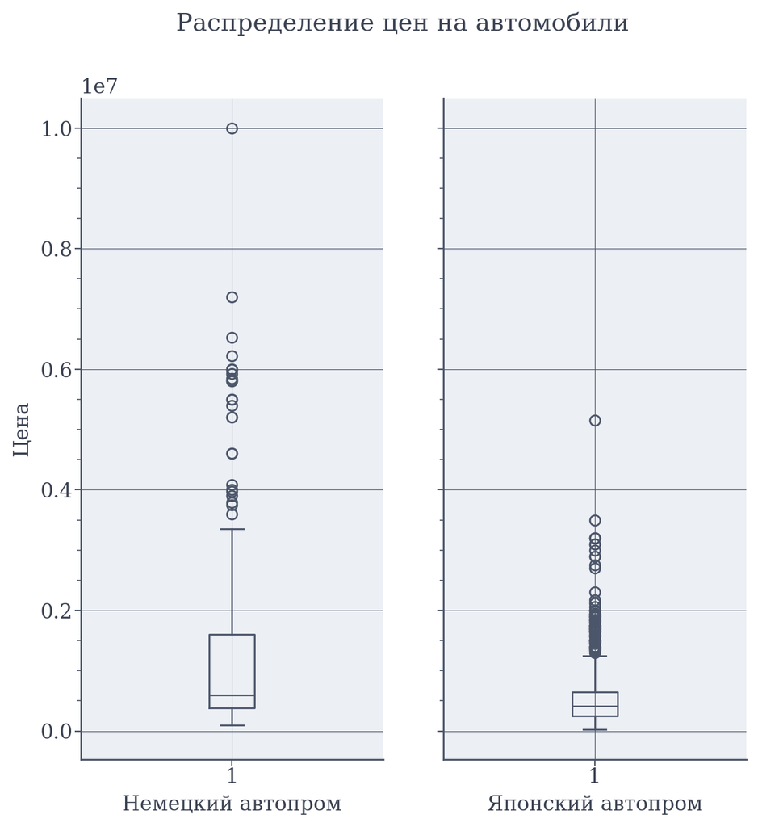

```python
fig, (ax1, ax2) = plt.subplots(1, 2, sharey=True,figsize=(7, 7), dpi=200)

ax1.boxplot(german_selling_price)
ax2.boxplot(japanese_selling_price)

ax1.set_ylabel("Цена")
ax1.set_xlabel("Немецкий автопром")
ax2.set_xlabel("Японский автопром")

fig.suptitle("Распределение цен на автомобили")

plt.show()
```

```python
pd.DataFrame(
    [
        [
            "Germany",
            round(np.mean(german_selling_price), 2),
            [round(x, 2) for x in t_conf_int(0.05, german_selling_price)],
        ],
        [
            "Japan",
            round(np.mean(japanese_selling_price), 2),
            [round(x, 2) for x in t_conf_int(0.05, japanese_selling_price)],
        ],
    ],
    columns=[
        "brand country",
        "selling price mean",
        "Conf int for selling price"
    ],
)
```

|  | brand country | selling price mean | Conf int for selling price |
| --- | --- | --- | --- |
| 0 | Germany | 1251011.88 | [1092964.35, 1409059.41] |
| 1 | Japan | 488922.30 | [474078.57, 503766.03] |

Получилось, что немецкий автопром дороже, чем японский. Возможно, он ценится больше, т.к. качество материалов и выполненной работы по автомобилю в целом выше, либо идет переплата за бренд. Так же возможно, что немецкие автомобили более долговечны и больше ценятся, так что не теряют в цене от перепродажи.

## Регрессионный анализ

Для построения регрессионной модели потребуется отбросить колонки `name` и `brand`, так как наименование автомобиля не должно влиять на ценник, а в колонке с брендом могут быть представлены не все бренды, которые могут присутствовать в выборке, подаваемой на анализ для предсказания.

```python
df_train = df.drop(columns=["name", "brand"])
df_train.head()
```

|  | year | selling_price | km_driven | fuel | seller_type | transmission | owner | mileage | engine | max_power | seats | max_torque | max_torque_rpm |
| --- | --- | --- | --- | --- | --- | --- | --- | --- | --- | --- | --- | --- | --- |
| 0 | 2014 | 450000 | 145500 | Diesel | Individual | Manual | First Owner | 23.40 | 1248 | 74.00 | 5 | 190 | 2000 |
| 1 | 2014 | 370000 | 120000 | Diesel | Individual | Manual | Second Owner | 21.14 | 1498 | 103.52 | 5 | 250 | 2500 |
| 2 | 2010 | 225000 | 127000 | Diesel | Individual | Manual | First Owner | 23.00 | 1396 | 90.00 | 5 | 220 | 2750 |
| 3 | 2007 | 130000 | 120000 | Petrol | Individual | Manual | First Owner | 16.10 | 1298 | 88.20 | 5 | 113 | 4500 |
| 4 | 2017 | 440000 | 45000 | Petrol | Individual | Manual | First Owner | 20.14 | 1197 | 81.86 | 5 | 114 | 4000 |

### Модель №0 (на численных фичах)

Для начала построим модель только на численных данных. Выберем численные и категориальные фитчи:

```python
numerical_features = [f for f in df_train.columns if df.dtypes[f] != "object"]
numerical_features.remove("selling_price")
print(numerical_features)

categorical_features = [f for f in df_train.columns if df.dtypes[f] == "object"]
print(categorical_features)
```

```
['year', 'km_driven', 'mileage', 'engine', 'max_power', 'seats', 'max_torque', 'max_torque_rpm']
['fuel', 'seller_type', 'transmission', 'owner']
```

Отнормируем численные данные

```python
scaler = StandardScaler()
scaled_features = scaler.fit_transform(df_train[numerical_features])
df_train_scaled = pd.DataFrame(scaled_features, columns=numerical_features)
df_train_scaled["selling_price"] = df_train["selling_price"]
df_train_scaled
```

|  | year | km_driven | mileage | engine | max_power | seats | max_torque | max_torque_rpm | selling_price |
| --- | --- | --- | --- | --- | --- | --- | --- | --- | --- |
| 0 | 0.091048 | 1.203906 | 0.968357 | -0.373084 | -0.434446 | -0.441255 | 0.137220 | -1.168960 | 450000 |
| 1 | 0.091048 | 0.779256 | 0.410162 | 0.135670 | 0.490688 | -0.441255 | 0.692758 | -0.608085 | 370000 |
| 2 | -0.938378 | 0.895826 | 0.869562 | -0.071901 | 0.066982 | -0.441255 | 0.414989 | -0.327647 | 225000 |
| 3 | -1.710447 | 0.779256 | -0.834663 | -0.271333 | 0.010571 | -0.441255 | -0.575719 | 1.635416 | 130000 |
| 4 | 0.863116 | -0.469715 | 0.163173 | -0.476870 | -0.188119 | -0.441255 | -0.566460 | 1.074541 | 440000 |
| ... | ... | ... | ... | ... | ... | ... | ... | ... | ... |
| 5815 | -1.453090 | 1.961614 | -0.385143 | -0.702757 | -0.807383 | -0.441255 | -0.733122 | -0.047209 | 120000 |
| 5816 | -0.166309 | -0.386450 | -0.143094 | -0.881838 | -0.650686 | -0.441255 | -0.788675 | 0.513666 | 260000 |
| 5817 | -0.166309 | 0.612726 | -0.241889 | -0.476870 | -0.157094 | -0.441255 | -0.566460 | 1.074541 | 320000 |
| 5818 | -1.710447 | 0.762603 | -0.661771 | 0.125495 | 0.693767 | -0.441255 | 0.553873 | -0.327647 | 135000 |
| 5819 | -1.195734 | 0.779256 | -0.044298 | -0.373084 | -0.437580 | -0.441255 | 0.137220 | -1.168960 | 382000 |

5820 rows × 9 columns

Обучим модель

```python
dataset, model_cars_0 = train_model(
    df_train_scaled,
    target="selling_price",
    feature_names=numerical_features,
    show_results=False,
    return_norm_tests=False,
)
print(model_cars_0.summary())
```

```
                            OLS Regression Results
==============================================================================
Dep. Variable:          selling_price   R-squared:                       0.602
Model:                            OLS   Adj. R-squared:                  0.601
Method:                 Least Squares   F-statistic:                     1098.
Date:                Mon, 25 Mar 2024   Prob (F-statistic):               0.00
Time:                        23:53:27   Log-Likelihood:                -82302.
No. Observations:                5820   AIC:                         1.646e+05
Df Residuals:                    5811   BIC:                         1.647e+05
Df Model:                           8
Covariance Type:            nonrobust
==================================================================================
                     coef    std err          t      P>|t|      [0.025      0.975]
----------------------------------------------------------------------------------
const           5.297e+05   4396.137    120.500      0.000    5.21e+05    5.38e+05
year            1.657e+05   5717.857     28.988      0.000    1.55e+05    1.77e+05
km_driven      -4.838e+04   5019.260     -9.639      0.000   -5.82e+04   -3.85e+04
mileage        -1.867e+04   7075.959     -2.638      0.008   -3.25e+04   -4796.492
engine          1.767e+04   9502.203      1.860      0.063    -952.887    3.63e+04
max_power        3.34e+05   7869.955     42.437      0.000    3.19e+05    3.49e+05
seats          -3.181e+04   6494.216     -4.899      0.000   -4.45e+04   -1.91e+04
max_torque     -3542.8524   6626.486     -0.535      0.593   -1.65e+04    9447.526
max_torque_rpm -6.986e+04   5718.056    -12.217      0.000   -8.11e+04   -5.86e+04
==============================================================================
Omnibus:                     6574.817   Durbin-Watson:                   1.644
Prob(Omnibus):                  0.000   Jarque-Bera (JB):          1068325.491
Skew:                           5.621   Prob(JB):                         0.00
Kurtosis:                      68.415   Cond. No.                         4.75
==============================================================================

Notes:
[1] Standard Errors assume that the covariance matrix of the errors is correctly specified.
```

Из репорта можно увидеть, что преременные `max_torque` и `engine` не сильно статзначимы. Можно попробовать не обучать на них модель. `R2 = 0.602`

Постром график важности фитчей

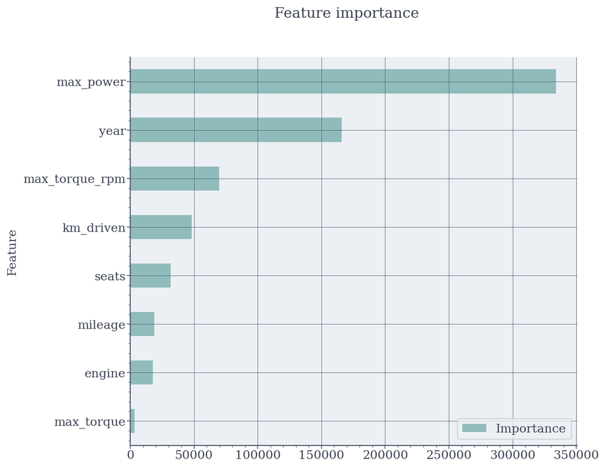

```python
tmp = model_cars_0.params.to_frame().iloc[1:]
feature_importance = pd.DataFrame({'Feature': tmp.index, 'Importance': np.abs(tmp[0].values)})
feature_importance = feature_importance.sort_values('Importance', ascending=True)

fig, ax = plt.subplots(figsize=(8, 7), dpi=150)
feature_importance.plot(x='Feature', y='Importance', kind='barh', ax=ax)
ax.legend(loc="lower right")
fig.suptitle("Feature importance")
plt.show()
```

Из графика видно, что самые значимые фитчи, это `max_power` и `year`.

Посмотрим на распределение остатков:

```python
norm_distr_check(
    (dataset["residuals"] - np.mean(dataset["residuals"]))
    / np.std(dataset["residuals"])
)
```

|  | test | p_level | a_level | a_calc | a_calc >= a_level | statistic | critical_value | statistic < critical_value | conclusion |
| --- | --- | --- | --- | --- | --- | --- | --- | --- | --- |
| 0 | Shapiro-Wilk test | 0.95 | 0.05 | 0.0 | False | 0.651374 |  |  | not gaussian distribution |
| 1 | Epps-Pulley test | 0.95 | 0.05 | - | - | - | - | False | count more than 1000 |
| 2 | D'Agostino's K-squared test | 0.95 | 0.05 | 0.0 | False | 6574.816605 |  |  | not gaussian distribution |
| 3 | Anderson-Darling test | 0.95 | 0.05 |  |  | 317.392928 | 0.786 | False | not gaussian distribution |
| 4 | Kolmogorov–Smirnov test | 0.95 | 0.05 | 0.0 | False | 0.163271 |  |  | not gaussian distribution |
| 5 | Lilliefors test | 0.95 | 0.05 | 0.001 | False | 0.163287 |  |  | not gaussian distribution |
| 6 | Cramér–von Mises test | 0.95 | 0.05 | 0.0 | False | 55.325216 |  |  | not gaussian distribution |
| 7 | Chi-squared test | 0.95 | 0.05 | 1.0 | True | -2383558250283498733568.0 |  |  | gaussian distribution |
| 8 | Jarque–Bera test | 0.95 | 0.05 | 0.0 | False | 1068325.490745 |  |  | not gaussian distribution |
| 9 | skewtest | 0.95 | 0.05 | 0.0 | False | 66.987715 |  |  | not gaussian distribution |
| 10 | kurtosistest | 0.95 | 0.05 | 0.0 | False | 45.688758 |  |  | not gaussian distribution |

Что-то не так: по тестам получилось, что распределение остатков не является гаусовым, и только Chi-Squared прошел тест.

Взглянем на графическое представление распределения остатков.

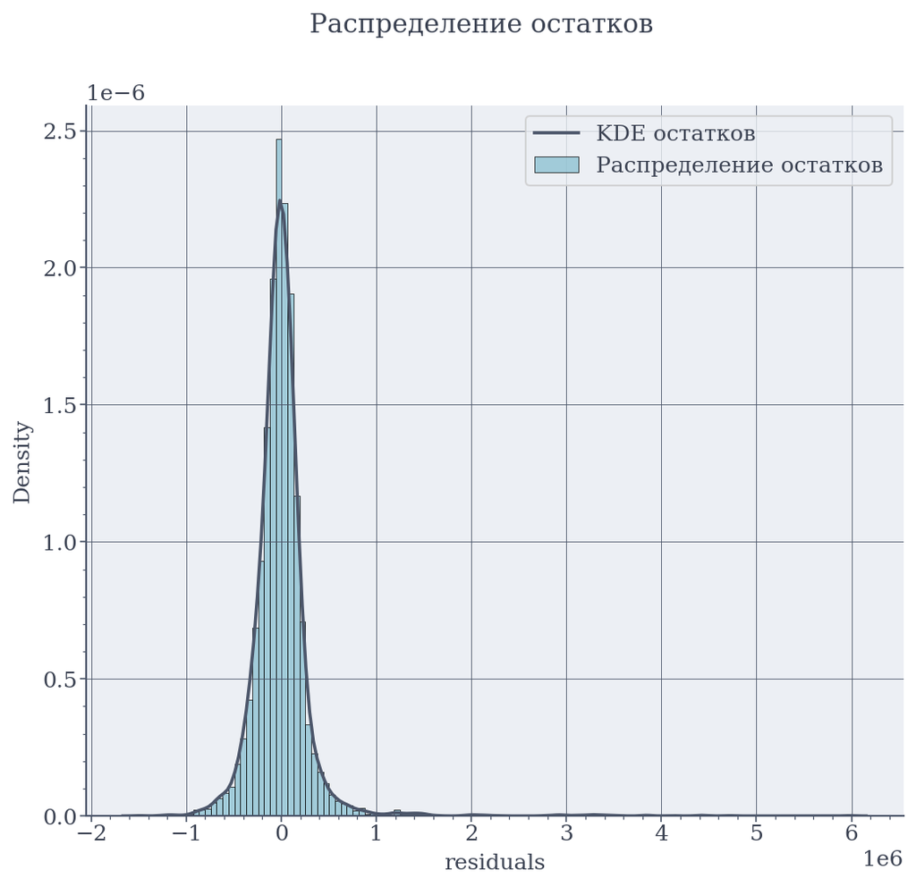

```python
fig, ax = plt.subplots(figsize=(8,7), dpi=150)


sns.histplot(
    dataset["residuals"],
    bins=120,
    ax=ax,
    stat="density",
    label="Распределение остатков",
    color=custom_pallete["light_gray_blue"],
)

sns.kdeplot(
    dataset["residuals"],
    color=custom_pallete["gray"],
    ax=ax,
    label="KDE остатков",
)

fig.suptitle("Распределение остатков")
plt.legend()
plt.show()
```

По графику видно, что распределение очень похоже на нормальное, только с неоднородностями в правом хвосте. Построим тот же график, но наложим поверх нормальное распределение (параметр scale подобран вручную).

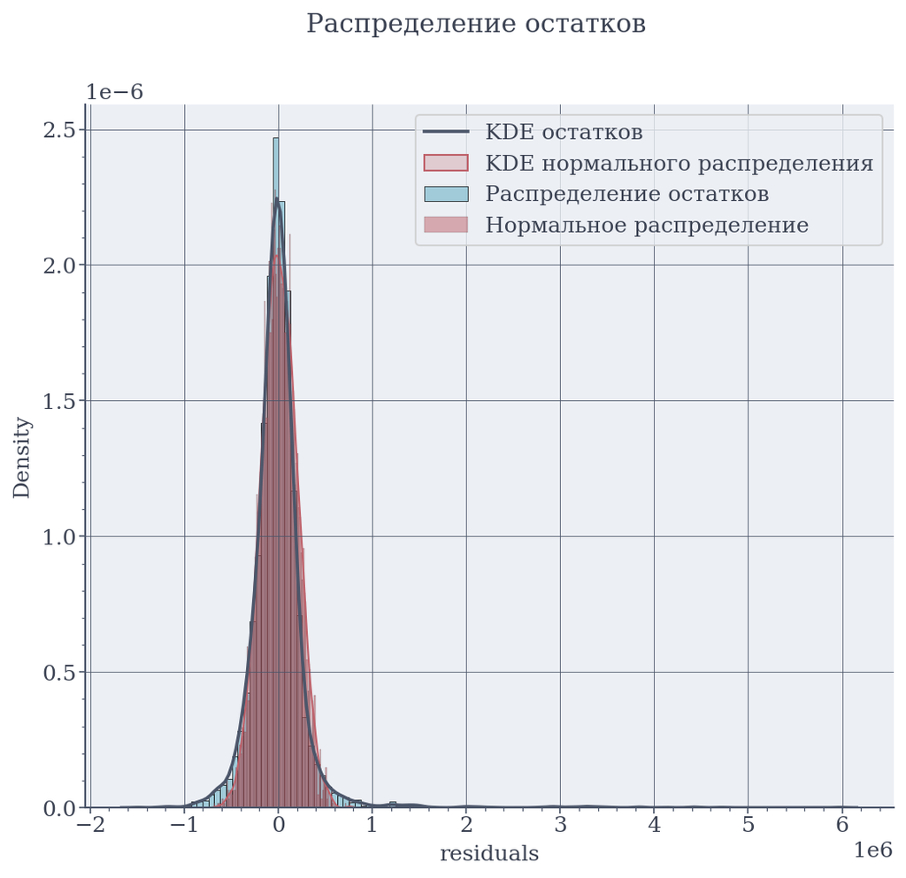

```python
fig, ax = plt.subplots(figsize=(8,7), dpi=150)


normal_x = np.random.normal(scale=0.19e6, size=5000)

sns.histplot(
    dataset["residuals"],
    bins=120,
    ax=ax,
    stat="density",
    label="Распределение остатков",
    color=custom_pallete["light_gray_blue"],
)

sns.kdeplot(
    dataset["residuals"],
    color=custom_pallete["gray"],
    ax=ax,
    label="KDE остатков",
)

sns.histplot(
    normal_x,
    bins=120,
    ax=ax,
    stat="density",
    label="Нормальное распределение",
    color=custom_pallete["red"],
    alpha=0.5,
)

sns.kdeplot(
    normal_x,
    color=custom_pallete["red"],
    ax=ax,
    label="KDE нормального распределения",
    fill=True,
)

fig.suptitle("Распределение остатков")
plt.legend()
plt.show()
```

Распределение почти совпадает с нормальным.

Также построим qqplot для распределения остатков

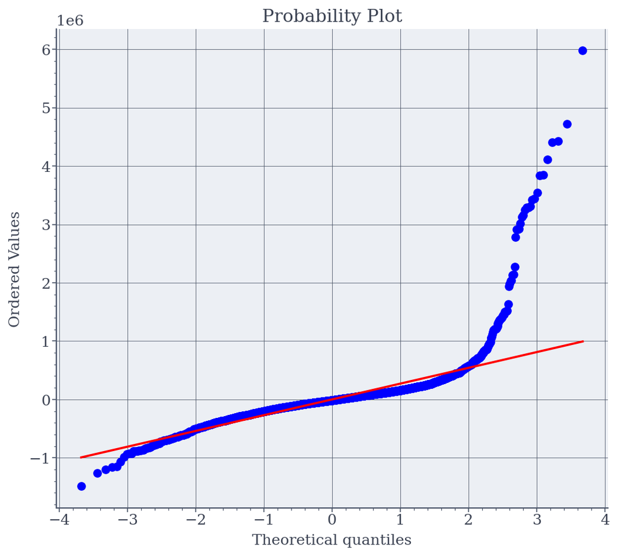

```python
fig, ax = plt.subplots(figsize=(8,7), dpi=150)
stats.probplot(x=dataset["residuals"], plot=ax)
plt.show()
```

По данному графику можно тоже видеть, что распределение в целом схоже с нормальным, только на правом хвосте сильно расходится.

В целом, я считаю, что можно работать с регрессионной моделью с таким распределением остатков. На мой взгляд распределение остатков "достаточно" нормальное.

Так же проведенем тест Голдфелда - Куандта на гетероскедастичность. $$H_0 = \{ \text{Имеет место гомоскедастичность}\}$$

```python
test = sm.stats.diagnostic.het_goldfeldquandt(y=df_train_scaled["selling_price"],x=df_train_scaled[numerical_features], drop=0.2)

print(f"pvalue = {test[1]}")
```

```
pvalue = 0.9999808748023373
```

$pvalue > 0.05$, следовательно нулевую гипотезу принимаем.

Проверим на мультиколинеарность (расчитаем VIF)

```python
calc_VIF(dataset=dataset, feature_names=numerical_features)
```

|  | Feature | VIF |
| --- | --- | --- |
| 0 | const | 1.000000 |
| 1 | year | 1.691703 |
| 2 | km_driven | 1.303578 |
| 3 | mileage | 2.590766 |
| 4 | engine | 4.672036 |
| 5 | max_power | 3.204808 |
| 6 | seats | 2.182283 |
| 7 | max_torque | 2.272082 |
| 8 | max_torque_rpm | 1.691821 |

VIF(`engine`) > 3, что может указывать на то, что данная переменная может быть выражена через другие. Также эта переменная не стат значимая P > |t|: P = 0.063

Дополнительно посмотрим как скоррелированны численные данные (для удобства окрасим только те квадраты, которые соотвтетствуют corr >= 0.6)

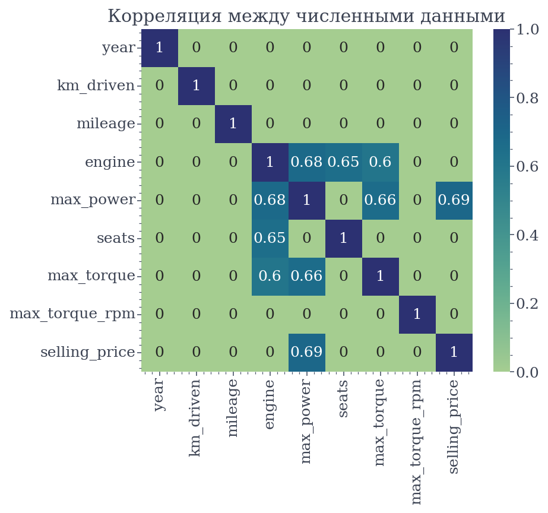

```python
corr = (
    df_train_scaled.corr()
    .apply(lambda x: np.abs(x))
    .apply(lambda x: np.where(x >= 0.6, x, 0.0))
)

# corr = np.where(corr >= 0.6, corr, 0.0)


plt.figure(figsize=(6, 5), dpi=150)

sns.heatmap(corr, cmap="crest", annot=True)

plt.title("Корреляция между численными данными")
plt.grid(False)
plt.show()
```

Действительно, переменная `engine` сильно коррелирует с `max_power`, `max_torque`, `seats`.

### Модель №1 (на численных фичах)

Согласно замечаниям, полученным из прошлой модели, внесем в нее изменения.

Обучим модель на численных фичах, исключив `engine`, `max_torque`:

```python
numerical_features_1 = [
    "year",
    "km_driven",
    "mileage",
    # "engine",
    "max_power",
    "seats",
    # "max_torque",
    "max_torque_rpm",
]
```

```python
dataset, model_cars_1 = train_model(
    df_train_scaled,
    target="selling_price",
    feature_names=numerical_features_1,
    show_results=False,
    return_norm_tests=False,
)
print(model_cars_1.summary())
```

```
                            OLS Regression Results
==============================================================================
Dep. Variable:          selling_price   R-squared:                       0.602
Model:                            OLS   Adj. R-squared:                  0.601
Method:                 Least Squares   F-statistic:                     1463.
Date:                Mon, 25 Mar 2024   Prob (F-statistic):               0.00
Time:                        23:53:30   Log-Likelihood:                -82303.
No. Observations:                5820   AIC:                         1.646e+05
Df Residuals:                    5813   BIC:                         1.647e+05
Df Model:                           6
Covariance Type:            nonrobust
==================================================================================
                     coef    std err          t      P>|t|      [0.025      0.975]
----------------------------------------------------------------------------------
const           5.297e+05   4396.744    120.484      0.000    5.21e+05    5.38e+05
year            1.666e+05   5700.057     29.223      0.000    1.55e+05    1.78e+05
km_driven      -4.709e+04   4971.981     -9.471      0.000   -5.68e+04   -3.73e+04
mileage        -2.354e+04   6575.430     -3.581      0.000   -3.64e+04   -1.07e+04
max_power       3.402e+05   5120.734     66.441      0.000     3.3e+05     3.5e+05
seats          -2.602e+04   5589.194     -4.655      0.000    -3.7e+04   -1.51e+04
max_torque_rpm -7.246e+04   5036.678    -14.387      0.000   -8.23e+04   -6.26e+04
==============================================================================
Omnibus:                     6552.528   Durbin-Watson:                   1.644
Prob(Omnibus):                  0.000   Jarque-Bera (JB):          1048460.762
Skew:                           5.592   Prob(JB):                         0.00
Kurtosis:                      67.795   Cond. No.                         2.86
==============================================================================

Notes:
[1] Standard Errors assume that the covariance matrix of the errors is correctly specified.
```

Регрессоры исключили, а результат не изменился - замечательно, избавились от фитчей, которые в лучшем случае не влияли на скор (`R2`).

Сделаем перерасчет VIF

```python
calc_VIF(dataset=dataset, feature_names=numerical_features_1)
```

|  | Feature | VIF |
| --- | --- | --- |
| 0 | const | 1.000000 |
| 1 | year | 1.680722 |
| 2 | km_driven | 1.278782 |
| 3 | mileage | 2.236587 |
| 4 | max_power | 1.356445 |
| 5 | seats | 1.615980 |
| 6 | max_torque_rpm | 1.312279 |

VIF для всех регрессоров меньше 3, что хорошо.

### Модель №2 (на численных и категориальных фичах)

#### Версия 2.0

Добавим категориальные фитчи

```python
df_train[categorical_features].describe()
```

|  | fuel | seller_type | transmission | owner |
| --- | --- | --- | --- | --- |
| count | 5820 | 5820 | 5820 | 5820 |
| unique | 4 | 3 | 2 | 5 |
| top | Diesel | Individual | Manual | First Owner |
| freq | 3175 | 5214 | 5322 | 3656 |

Закодируем категориальные фитчи

```python
encoder = OneHotEncoder(drop='first')
encoder.fit(df_train[categorical_features])

codes = encoder.transform(df_train[categorical_features]).toarray()
enc_features_names = encoder.get_feature_names_out(categorical_features)

df_train_all = pd.concat(
    [
        df_train_scaled,
        pd.DataFrame(codes, columns=enc_features_names).astype(int),
    ],
    axis=1,
)
df_train_all
```

|  | year | km_driven | mileage | engine | max_power | seats | max_torque | max_torque_rpm | selling_price | fuel_Diesel | fuel_LPG | fuel_Petrol | seller_type_Individual | seller_type_Trustmark Dealer | transmission_Manual | owner_Fourth & Above Owner | owner_Second Owner | owner_Test Drive Car | owner_Third Owner |
| --- | --- | --- | --- | --- | --- | --- | --- | --- | --- | --- | --- | --- | --- | --- | --- | --- | --- | --- | --- |
| 0 | 0.091048 | 1.203906 | 0.968357 | -0.373084 | -0.434446 | -0.441255 | 0.137220 | -1.168960 | 450000 | 1 | 0 | 0 | 1 | 0 | 1 | 0 | 0 | 0 | 0 |
| 1 | 0.091048 | 0.779256 | 0.410162 | 0.135670 | 0.490688 | -0.441255 | 0.692758 | -0.608085 | 370000 | 1 | 0 | 0 | 1 | 0 | 1 | 0 | 1 | 0 | 0 |
| 2 | -0.938378 | 0.895826 | 0.869562 | -0.071901 | 0.066982 | -0.441255 | 0.414989 | -0.327647 | 225000 | 1 | 0 | 0 | 1 | 0 | 1 | 0 | 0 | 0 | 0 |
| 3 | -1.710447 | 0.779256 | -0.834663 | -0.271333 | 0.010571 | -0.441255 | -0.575719 | 1.635416 | 130000 | 0 | 0 | 1 | 1 | 0 | 1 | 0 | 0 | 0 | 0 |
| 4 | 0.863116 | -0.469715 | 0.163173 | -0.476870 | -0.188119 | -0.441255 | -0.566460 | 1.074541 | 440000 | 0 | 0 | 1 | 1 | 0 | 1 | 0 | 0 | 0 | 0 |
| ... | ... | ... | ... | ... | ... | ... | ... | ... | ... | ... | ... | ... | ... | ... | ... | ... | ... | ... | ... |
| 5815 | -1.453090 | 1.961614 | -0.385143 | -0.702757 | -0.807383 | -0.441255 | -0.733122 | -0.047209 | 120000 | 0 | 0 | 1 | 1 | 0 | 1 | 0 | 0 | 0 | 0 |
| 5816 | -0.166309 | -0.386450 | -0.143094 | -0.881838 | -0.650686 | -0.441255 | -0.788675 | 0.513666 | 260000 | 0 | 0 | 1 | 1 | 0 | 1 | 0 | 1 | 0 | 0 |
| 5817 | -0.166309 | 0.612726 | -0.241889 | -0.476870 | -0.157094 | -0.441255 | -0.566460 | 1.074541 | 320000 | 0 | 0 | 1 | 1 | 0 | 1 | 0 | 0 | 0 | 0 |
| 5818 | -1.710447 | 0.762603 | -0.661771 | 0.125495 | 0.693767 | -0.441255 | 0.553873 | -0.327647 | 135000 | 1 | 0 | 0 | 1 | 0 | 1 | 1 | 0 | 0 | 0 |
| 5819 | -1.195734 | 0.779256 | -0.044298 | -0.373084 | -0.437580 | -0.441255 | 0.137220 | -1.168960 | 382000 | 1 | 0 | 0 | 1 | 0 | 1 | 0 | 0 | 0 | 0 |

5820 rows × 19 columns

Обучаем модель

```python
dataset, model_cars_2 = train_model(
    df_train_all,
    target="selling_price",
    feature_names=numerical_features_1 + enc_features_names.tolist(),
    show_results=False,
    return_norm_tests=False,
)
print(model_cars_2.summary())
```

```
                            OLS Regression Results
==============================================================================
Dep. Variable:          selling_price   R-squared:                       0.661
Model:                            OLS   Adj. R-squared:                  0.660
Method:                 Least Squares   F-statistic:                     707.2
Date:                Mon, 25 Mar 2024   Prob (F-statistic):               0.00
Time:                        23:53:30   Log-Likelihood:                -81834.
No. Observations:                5820   AIC:                         1.637e+05
Df Residuals:                    5803   BIC:                         1.638e+05
Df Model:                          16
Covariance Type:            nonrobust
================================================================================================
                                   coef    std err          t      P>|t|      [0.025      0.975]
------------------------------------------------------------------------------------------------
const                         9.654e+05   4.99e+04     19.336      0.000    8.68e+05    1.06e+06
year                           1.43e+05   5716.711     25.022      0.000    1.32e+05    1.54e+05
km_driven                    -2.857e+04   4722.343     -6.050      0.000   -3.78e+04   -1.93e+04
mileage                      -1452.1561   6288.535     -0.231      0.817   -1.38e+04    1.09e+04
max_power                     3.119e+05   5901.931     52.853      0.000       3e+05    3.24e+05
seats                         2201.5127   5428.480      0.406      0.685   -8440.332    1.28e+04
max_torque_rpm               -1.125e+05   7288.330    -15.429      0.000   -1.27e+05   -9.82e+04
fuel_Diesel                  -1.067e+05   4.74e+04     -2.253      0.024      -2e+05   -1.39e+04
fuel_LPG                      1.451e+05   7.24e+04      2.002      0.045    3048.393    2.87e+05
fuel_Petrol                  -1405.1986   4.67e+04     -0.030      0.976   -9.29e+04    9.01e+04
seller_type_Individual       -1.116e+05   1.42e+04     -7.848      0.000   -1.39e+05   -8.37e+04
seller_type_Trustmark Dealer -1.135e+05   6.35e+04     -1.788      0.074   -2.38e+05    1.09e+04
transmission_Manual          -2.814e+05   1.69e+04    -16.608      0.000   -3.15e+05   -2.48e+05
owner_Fourth & Above Owner   -5.611e+04   2.92e+04     -1.924      0.054   -1.13e+05    1047.391
owner_Second Owner           -6.091e+04   1.02e+04     -5.998      0.000   -8.08e+04    -4.1e+04
owner_Test Drive Car           3.26e+06   1.56e+05     20.891      0.000    2.95e+06    3.57e+06
owner_Third Owner             -5.54e+04   1.72e+04     -3.227      0.001   -8.91e+04   -2.17e+04
==============================================================================
Omnibus:                     5954.339   Durbin-Watson:                   1.774
Prob(Omnibus):                  0.000   Jarque-Bera (JB):           897150.591
Skew:                           4.710   Prob(JB):                         0.00
Kurtosis:                      63.090   Cond. No.                         69.7
==============================================================================

Notes:
[1] Standard Errors assume that the covariance matrix of the errors is correctly specified.
```

Скор стал выше, но так же теперь появились новые не статзначимые переменные

Также расчитаем VIF

```python
calc_VIF(dataset=dataset, feature_names=numerical_features_1 + enc_features_names.tolist())
```

|  | Feature | VIF |
| --- | --- | --- |
| 0 | const | 151.289172 |
| 1 | year | 1.983201 |
| 2 | km_driven | 1.353285 |
| 3 | mileage | 2.399790 |
| 4 | max_power | 2.113793 |
| 5 | seats | 1.788260 |
| 6 | max_torque_rpm | 3.223519 |
| 7 | fuel_Diesel | 33.772828 |
| 8 | fuel_LPG | 1.687529 |
| 9 | fuel_Petrol | 32.591177 |
| 10 | seller_type_Individual | 1.144849 |
| 11 | seller_type_Trustmark Dealer | 1.045212 |
| 12 | transmission_Manual | 1.362918 |
| 13 | owner_Fourth & Above Owner | 1.101194 |
| 14 | owner_Second Owner | 1.254467 |
| 15 | owner_Test Drive Car | 1.015115 |
| 16 | owner_Third Owner | 1.195275 |

Попробуем скорректировать модель, ориентируясь на полученные расчеты

#### Верисия 2.1

Отбросим не стат. значимые численные и категориальные переменные

```python
numerical_features_2_1 = [
    "year",
    "km_driven",
    # "mileage",
    "max_power",
    # "seats",
    "max_torque_rpm",
]

enc_features_names_corrected_2_1 = [
    "fuel_Diesel",
    "fuel_LPG",
    # "fuel_Petrol",
    "seller_type_Individual",
    # "seller_type_Trustmark Dealer",
    "transmission_Manual",
    # "owner_Fourth & Above Owner",
    "owner_Second Owner",
    "owner_Test Drive Car",
    "owner_Third Owner",
]
```

```python
dataset, model_cars_2_1 = train_model(
    df_train_all,
    target="selling_price",
    feature_names=numerical_features_2_1 + enc_features_names_corrected_2_1,
    show_results=False,
    return_norm_tests=False,
)
print(model_cars_2_1.summary())
```

```
                            OLS Regression Results
==============================================================================
Dep. Variable:          selling_price   R-squared:                       0.661
Model:                            OLS   Adj. R-squared:                  0.660
Method:                 Least Squares   F-statistic:                     1028.
Date:                Mon, 25 Mar 2024   Prob (F-statistic):               0.00
Time:                        23:53:30   Log-Likelihood:                -81838.
No. Observations:                5820   AIC:                         1.637e+05
Df Residuals:                    5808   BIC:                         1.638e+05
Df Model:                          11
Covariance Type:            nonrobust
==========================================================================================
                             coef    std err          t      P>|t|      [0.025      0.975]
------------------------------------------------------------------------------------------
const                   9.556e+05      2e+04     47.763      0.000    9.16e+05    9.95e+05
year                    1.447e+05   4892.525     29.576      0.000    1.35e+05    1.54e+05
km_driven              -2.847e+04   4685.319     -6.076      0.000   -3.77e+04   -1.93e+04
max_power                3.13e+05   5315.540     58.876      0.000    3.03e+05    3.23e+05
max_torque_rpm         -1.123e+05   7234.209    -15.518      0.000   -1.26e+05   -9.81e+04
fuel_Diesel            -1.036e+05   1.58e+04     -6.541      0.000   -1.35e+05   -7.26e+04
fuel_LPG                1.478e+05   5.61e+04      2.635      0.008    3.78e+04    2.58e+05
seller_type_Individual -1.076e+05   1.39e+04     -7.727      0.000   -1.35e+05   -8.03e+04
transmission_Manual    -2.804e+05   1.68e+04    -16.653      0.000   -3.13e+05   -2.47e+05
owner_Second Owner     -5.729e+04   9939.452     -5.764      0.000   -7.68e+04   -3.78e+04
owner_Test Drive Car    3.264e+06   1.56e+05     20.915      0.000    2.96e+06    3.57e+06
owner_Third Owner      -5.061e+04    1.7e+04     -2.984      0.003   -8.39e+04   -1.74e+04
==============================================================================
Omnibus:                     5940.908   Durbin-Watson:                   1.776
Prob(Omnibus):                  0.000   Jarque-Bera (JB):           885628.711
Skew:                           4.695   Prob(JB):                         0.00
Kurtosis:                      62.698   Cond. No.                         68.0
==============================================================================

Notes:
[1] Standard Errors assume that the covariance matrix of the errors is correctly specified.
```

Скор не изменился. Избавились от лишних регрессоров.

Посмотрим: какие фитчи были наиболее важными для этой модели

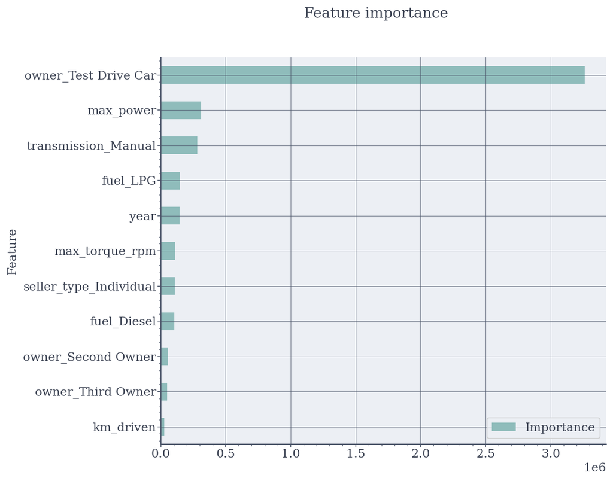

```python
tmp = model_cars_2_1.params.to_frame().iloc[1:]
feature_importance = pd.DataFrame({'Feature': tmp.index, 'Importance': np.abs(tmp[0].values)})
feature_importance = feature_importance.sort_values('Importance', ascending=True)

fig, ax = plt.subplots(figsize=(8, 7), dpi=150)
feature_importance.plot(x='Feature', y='Importance', kind='barh', ax=ax)
ax.legend(loc="lower right")
fig.suptitle("Feature importance")
plt.show()
```

Наиболее важной фитчей оказалось количество владельцев, а именно `owner_Test Drive Car`.

### Модель №3.0 (на численных и категориальных фичах)

Все таки кажется, что фитча seats может быть значимой. Попробуем перенести ее из численных фитчей в категориальные.

Преобразуем число сидений через onehotencoder

```python
encoder = OneHotEncoder(drop='first')
encoder.fit(df_train[categorical_features + ["seats"]])

codes = encoder.transform(df_train[categorical_features + ["seats"]]).toarray()
enc_features_names = encoder.get_feature_names_out(categorical_features + ["seats"])

df_train_all = pd.concat(
    [
        df_train_scaled.drop(columns=["seats"]),
        pd.DataFrame(codes, columns=enc_features_names).astype(int),
    ],
    axis=1,
)
df_train_all
```

|  | year | km_driven | mileage | engine | max_power | max_torque | max_torque_rpm | selling_price | fuel_Diesel | fuel_LPG | ... | owner_Test Drive Car | owner_Third Owner | seats_4 | seats_5 | seats_6 | seats_7 | seats_8 | seats_9 | seats_10 | seats_14 |
| --- | --- | --- | --- | --- | --- | --- | --- | --- | --- | --- | --- | --- | --- | --- | --- | --- | --- | --- | --- | --- | --- |
| 0 | 0.091048 | 1.203906 | 0.968357 | -0.373084 | -0.434446 | 0.137220 | -1.168960 | 450000 | 1 | 0 | ... | 0 | 0 | 0 | 1 | 0 | 0 | 0 | 0 | 0 | 0 |
| 1 | 0.091048 | 0.779256 | 0.410162 | 0.135670 | 0.490688 | 0.692758 | -0.608085 | 370000 | 1 | 0 | ... | 0 | 0 | 0 | 1 | 0 | 0 | 0 | 0 | 0 | 0 |
| 2 | -0.938378 | 0.895826 | 0.869562 | -0.071901 | 0.066982 | 0.414989 | -0.327647 | 225000 | 1 | 0 | ... | 0 | 0 | 0 | 1 | 0 | 0 | 0 | 0 | 0 | 0 |
| 3 | -1.710447 | 0.779256 | -0.834663 | -0.271333 | 0.010571 | -0.575719 | 1.635416 | 130000 | 0 | 0 | ... | 0 | 0 | 0 | 1 | 0 | 0 | 0 | 0 | 0 | 0 |
| 4 | 0.863116 | -0.469715 | 0.163173 | -0.476870 | -0.188119 | -0.566460 | 1.074541 | 440000 | 0 | 0 | ... | 0 | 0 | 0 | 1 | 0 | 0 | 0 | 0 | 0 | 0 |
| ... | ... | ... | ... | ... | ... | ... | ... | ... | ... | ... | ... | ... | ... | ... | ... | ... | ... | ... | ... | ... | ... |
| 5815 | -1.453090 | 1.961614 | -0.385143 | -0.702757 | -0.807383 | -0.733122 | -0.047209 | 120000 | 0 | 0 | ... | 0 | 0 | 0 | 1 | 0 | 0 | 0 | 0 | 0 | 0 |
| 5816 | -0.166309 | -0.386450 | -0.143094 | -0.881838 | -0.650686 | -0.788675 | 0.513666 | 260000 | 0 | 0 | ... | 0 | 0 | 0 | 1 | 0 | 0 | 0 | 0 | 0 | 0 |
| 5817 | -0.166309 | 0.612726 | -0.241889 | -0.476870 | -0.157094 | -0.566460 | 1.074541 | 320000 | 0 | 0 | ... | 0 | 0 | 0 | 1 | 0 | 0 | 0 | 0 | 0 | 0 |
| 5818 | -1.710447 | 0.762603 | -0.661771 | 0.125495 | 0.693767 | 0.553873 | -0.327647 | 135000 | 1 | 0 | ... | 0 | 0 | 0 | 1 | 0 | 0 | 0 | 0 | 0 | 0 |
| 5819 | -1.195734 | 0.779256 | -0.044298 | -0.373084 | -0.437580 | 0.137220 | -1.168960 | 382000 | 1 | 0 | ... | 0 | 0 | 0 | 1 | 0 | 0 | 0 | 0 | 0 | 0 |

5820 rows × 26 columns

Получаем следующие фитчи, на которых будем обучать модель

```python
numerical_features_3_0 = [
    "year",
    "km_driven",
    "mileage",
    "max_power",
    # "seats",
    "max_torque_rpm",
]

enc_features_names_3_0 = [
    "fuel_Diesel",
    "fuel_LPG",
    "fuel_Petrol",
    "seller_type_Individual",
    "seller_type_Trustmark Dealer",
    "transmission_Manual",
    "owner_Fourth & Above Owner",
    "owner_Second Owner",
    "owner_Test Drive Car",
    "owner_Third Owner",
    "seats_4",
    "seats_5",
    "seats_6",
    "seats_7",
    "seats_8",
    "seats_9",
    "seats_10",
    "seats_14",
]
```

Обучаем модель

```python
dataset, model_cars_3_0 = train_model(
    df_train_all,
    target="selling_price",
    feature_names=numerical_features_3_0 + enc_features_names_3_0,
    show_results=False,
    return_norm_tests=False,
)
print(model_cars_3_0.summary())
```

```
                            OLS Regression Results
==============================================================================
Dep. Variable:          selling_price   R-squared:                       0.675
Model:                            OLS   Adj. R-squared:                  0.674
Method:                 Least Squares   F-statistic:                     524.4
Date:                Mon, 25 Mar 2024   Prob (F-statistic):               0.00
Time:                        23:53:30   Log-Likelihood:                -81707.
No. Observations:                5820   AIC:                         1.635e+05
Df Residuals:                    5796   BIC:                         1.636e+05
Df Model:                          23
Covariance Type:            nonrobust
================================================================================================
                                   coef    std err          t      P>|t|      [0.025      0.975]
------------------------------------------------------------------------------------------------
const                         1.016e+06   2.23e+05      4.551      0.000    5.79e+05    1.45e+06
year                          1.593e+05   5769.483     27.605      0.000    1.48e+05    1.71e+05
km_driven                    -2.386e+04   4639.366     -5.144      0.000    -3.3e+04   -1.48e+04
mileage                       7752.9845   6375.845      1.216      0.224   -4746.052    2.03e+04
max_power                      3.17e+05   5873.316     53.971      0.000    3.05e+05    3.29e+05
max_torque_rpm               -9.387e+04   7318.916    -12.825      0.000   -1.08e+05   -7.95e+04
fuel_Diesel                  -6.537e+04   4.65e+04     -1.406      0.160   -1.56e+05    2.57e+04
fuel_LPG                      1.902e+05    7.1e+04      2.679      0.007     5.1e+04    3.29e+05
fuel_Petrol                   1.201e+04   4.57e+04      0.263      0.793   -7.76e+04    1.02e+05
seller_type_Individual        -1.09e+05   1.39e+04     -7.819      0.000   -1.36e+05   -8.16e+04
seller_type_Trustmark Dealer -1.095e+05   6.21e+04     -1.763      0.078   -2.31e+05    1.23e+04
transmission_Manual          -2.676e+05   1.67e+04    -16.057      0.000      -3e+05   -2.35e+05
owner_Fourth & Above Owner   -5.007e+04   2.86e+04     -1.753      0.080   -1.06e+05    5921.413
owner_Second Owner           -5.301e+04   9962.143     -5.321      0.000   -7.25e+04   -3.35e+04
owner_Test Drive Car          3.261e+06   1.53e+05     21.341      0.000    2.96e+06    3.56e+06
owner_Third Owner            -4.346e+04   1.68e+04     -2.581      0.010   -7.65e+04   -1.05e+04
seats_4                       3.975e+05   2.21e+05      1.798      0.072   -3.58e+04    8.31e+05
seats_5                      -1.123e+05   2.18e+05     -0.515      0.607    -5.4e+05    3.16e+05
seats_6                      -2.173e+05   2.22e+05     -0.979      0.327   -6.52e+05    2.18e+05
seats_7                      -9.098e+04   2.17e+05     -0.419      0.676   -5.17e+05    3.35e+05
seats_8                      -2.357e+04   2.18e+05     -0.108      0.914   -4.51e+05    4.03e+05
seats_9                      -5.818e+04   2.19e+05     -0.265      0.791   -4.88e+05    3.72e+05
seats_10                     -2.864e+04   2.28e+05     -0.126      0.900   -4.76e+05    4.18e+05
seats_14                     -2.081e+05   3.73e+05     -0.559      0.576   -9.38e+05    5.22e+05
==============================================================================
Omnibus:                     5649.907   Durbin-Watson:                   1.771
Prob(Omnibus):                  0.000   Jarque-Bera (JB):           726213.752
Skew:                           4.345   Prob(JB):                         0.00
Kurtosis:                      57.029   Cond. No.                         330.
==============================================================================

Notes:
[1] Standard Errors assume that the covariance matrix of the errors is correctly specified.
```

Взглянем на VIF

```python
calc_VIF(dataset=dataset, feature_names=numerical_features_3_0 + enc_features_names_3_0)
```

|  | Feature | VIF |
| --- | --- | --- |
| 0 | const | 3157.739977 |
| 1 | year | 2.107144 |
| 2 | km_driven | 1.362504 |
| 3 | mileage | 2.573332 |
| 4 | max_power | 2.183670 |
| 5 | max_torque_rpm | 3.390892 |
| 6 | fuel_Diesel | 33.900881 |
| 7 | fuel_LPG | 1.690631 |
| 8 | fuel_Petrol | 32.635254 |
| 9 | seller_type_Individual | 1.146802 |
| 10 | seller_type_Trustmark Dealer | 1.045306 |
| 11 | transmission_Manual | 1.375412 |
| 12 | owner_Fourth & Above Owner | 1.102147 |
| 13 | owner_Second Owner | 1.259078 |
| 14 | owner_Test Drive Car | 1.015373 |
| 15 | owner_Third Owner | 1.199216 |
| 16 | seats_4 | 50.703470 |
| 17 | seats_5 | 509.281585 |
| 18 | seats_6 | 26.026465 |
| 19 | seats_7 | 361.959345 |
| 20 | seats_8 | 97.282085 |
| 21 | seats_9 | 35.708704 |
| 22 | seats_10 | 10.142286 |
| 23 | seats_14 | 1.509028 |

`R2` стал больше. Остальные выводы по данной модели аналогичны прошлому случаю, только с поправкой на новые данные. Перейдем сразу к следующей версии модели.

#### Версия 3.1

Как и в прошлом случае избавляемся от не стат. значимых переменных и от переменных с большим VIF

```python
numerical_features_3_1 = [
    "year",
    "km_driven",
    # "mileage",
    "max_power",
    # "seats",
    "max_torque_rpm",
]

enc_features_names_3_1 = [
    "fuel_Diesel",
    "fuel_LPG",
    # "fuel_Petrol",
    "seller_type_Individual",
    # "seller_type_Trustmark Dealer",
    "transmission_Manual",
    # "owner_Fourth & Above Owner",
    "owner_Second Owner",
    "owner_Test Drive Car",
    "owner_Third Owner",
    "seats_4",
    # "seats_5",
    "seats_6",
    # "seats_7",
    "seats_8",
    # "seats_9",
    # "seats_10",
    # "seats_14",
]

dataset, model_cars_3_1 = train_model(
    df_train_all,
    target="selling_price",
    feature_names=numerical_features_3_1 + enc_features_names_3_1,
    show_results=False,
    return_norm_tests=False,
)
print(model_cars_3_1.summary())
```

```
                            OLS Regression Results
==============================================================================
Dep. Variable:          selling_price   R-squared:                       0.675
Model:                            OLS   Adj. R-squared:                  0.674
Method:                 Least Squares   F-statistic:                     860.5
Date:                Mon, 25 Mar 2024   Prob (F-statistic):               0.00
Time:                        23:53:30   Log-Likelihood:                -81713.
No. Observations:                5820   AIC:                         1.635e+05
Df Residuals:                    5805   BIC:                         1.636e+05
Df Model:                          14
Covariance Type:            nonrobust
==========================================================================================
                             coef    std err          t      P>|t|      [0.025      0.975]
------------------------------------------------------------------------------------------
const                   9.063e+05   1.99e+04     45.622      0.000    8.67e+05    9.45e+05
year                    1.645e+05   4950.784     33.229      0.000    1.55e+05    1.74e+05
km_driven              -2.359e+04   4611.635     -5.114      0.000   -3.26e+04   -1.45e+04
max_power               3.151e+05   5206.437     60.517      0.000    3.05e+05    3.25e+05
max_torque_rpm         -9.537e+04   7246.615    -13.161      0.000    -1.1e+05   -8.12e+04
fuel_Diesel            -6.973e+04   1.59e+04     -4.391      0.000   -1.01e+05   -3.86e+04
fuel_LPG                1.788e+05    5.5e+04      3.253      0.001     7.1e+04    2.86e+05
seller_type_Individual -1.044e+05   1.36e+04     -7.650      0.000   -1.31e+05   -7.76e+04
transmission_Manual    -2.639e+05   1.65e+04    -15.973      0.000   -2.96e+05   -2.32e+05
owner_Second Owner     -5.049e+04   9740.768     -5.184      0.000   -6.96e+04   -3.14e+04
owner_Test Drive Car    3.264e+06   1.53e+05     21.360      0.000    2.96e+06    3.56e+06
owner_Third Owner      -4.003e+04   1.66e+04     -2.408      0.016   -7.26e+04   -7442.296
seats_4                 5.112e+05   3.32e+04     15.412      0.000    4.46e+05    5.76e+05
seats_6                -1.121e+05   4.38e+04     -2.561      0.010   -1.98e+05   -2.63e+04
seats_8                 7.206e+04   2.25e+04      3.204      0.001     2.8e+04    1.16e+05
==============================================================================
Omnibus:                     5670.437   Durbin-Watson:                   1.773
Prob(Omnibus):                  0.000   Jarque-Bera (JB):           739728.872
Skew:                           4.368   Prob(JB):                         0.00
Kurtosis:                      57.535   Cond. No.                         68.1
==============================================================================

Notes:
[1] Standard Errors assume that the covariance matrix of the errors is correctly specified.
```

Посмотрим на важность фитчей для этой модели

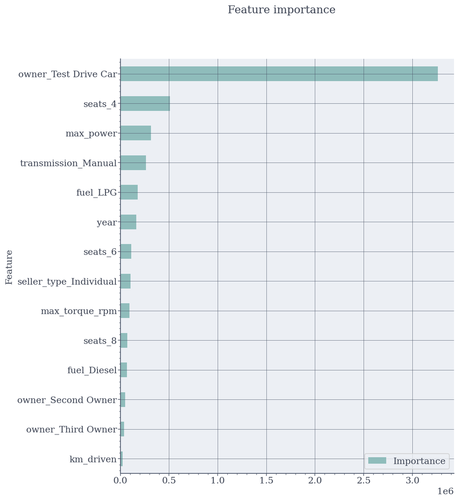

```python
tmp = model_cars_3_1.params.to_frame().iloc[1:]
feature_importance = pd.DataFrame(
    {
        "Feature": tmp.index,
        "Importance": np.abs(tmp[0].values),
    }
)
feature_importance = feature_importance.sort_values("Importance", ascending=True)

fig, ax = plt.subplots(figsize=(8, 10), dpi=150)

feature_importance.plot(
    x="Feature",
    y="Importance",
    kind="barh",
    ax=ax,
)

ax.legend(loc="lower right")

fig.suptitle("Feature importance")
plt.show()
```

как и в прошлом случае, наиболее важной фитчей оказалось количество владельцев, а именно `owner_Test Drive Car`, однако на втором месте идет фитча `seats_4`, добавленная в этой модели, что учазывает на то, что ценник зависи от количества сидений в автомобиле (ровно ли их 4).

### Дополительный EDA

Построим pairplot для selling_price относительно всех переменных

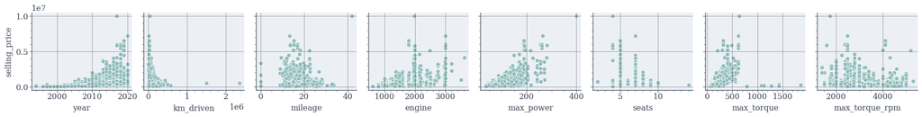

```python
sns.pairplot(df_train, x_vars=numerical_features, y_vars="selling_price")
plt.show()
```

Из данных графиков можно предположить, что распределение selling_price относительно параметров year, km_driven и max_torque, стоит попробовать аппроксимировать экспонентой или квадратичной функцией. Проверим это далее.

Остновные численные фитчи

```python
numerical_features_3_2 = [
    "year",
    "km_driven",
    "mileage",
    "engine",
    "max_power",
    # "seats",
    "max_torque",
    "max_torque_rpm",
]

df_train_3_2 = df_train[numerical_features_3_2]
```

Отнормируем и добавим новые производные фитчи

```python
scaler = StandardScaler()
scaled_features = scaler.fit_transform(df_train_3_2[numerical_features_3_2])

df_train_3_2_scaled = pd.DataFrame(
    scaled_features,
    columns=numerical_features_3_2,
)

df_train_3_2_scaled["year_exp"] = np.exp(df_train_3_2_scaled["year"])
df_train_3_2_scaled["km_driven_exp"] = np.exp(-df_train_3_2_scaled["km_driven"])
df_train_3_2_scaled["max_torque_exp"] = np.exp(df_train_3_2_scaled["max_torque"])

df_train_3_2_scaled["year_squared"] = np.power(df_train_3_2_scaled["year"], 2)
df_train_3_2_scaled["km_driven_squared"] = np.power(df_train_3_2_scaled["km_driven"], 2)
df_train_3_2_scaled["max_torque_squared"] = np.power(df_train_3_2_scaled["max_torque"], 2)

numerical_features_3_2 = numerical_features_3_2 + [
    "year_exp",
    "km_driven_exp",
    "max_torque_exp",

    "year_squared",
    "km_driven_squared",
    "max_torque_squared",
]

scaled_features = scaler.fit_transform(
    df_train_3_2_scaled[numerical_features_3_2]
)

df_train_3_2_scaled = pd.DataFrame(
    scaled_features,
    columns=numerical_features_3_2,
)

df_train_3_2_scaled["selling_price"] = df_train["selling_price"]

df_train_3_2_scaled
```

|  | year | km_driven | mileage | engine | max_power | max_torque | max_torque_rpm | year_exp | km_driven_exp | max_torque_exp | year_squared | km_driven_squared | max_torque_squared | selling_price |
| --- | --- | --- | --- | --- | --- | --- | --- | --- | --- | --- | --- | --- | --- | --- |
| 0 | 0.091048 | 1.203906 | 0.968357 | -0.373084 | -0.434446 | 0.137220 | -1.168960 | -0.328101 | -1.268263 | -0.015336 | -0.558239 | 0.021922 | -0.137642 | 450000 |
| 1 | 0.091048 | 0.779256 | 0.410162 | 0.135670 | 0.490688 | 0.692758 | -0.608085 | -0.328101 | -1.063661 | -0.015326 | -0.558239 | -0.019160 | -0.072960 | 370000 |
| 2 | -0.938378 | 0.895826 | 0.869562 | -0.071901 | 0.066982 | 0.414989 | -0.327647 | -0.954520 | -1.128727 | -0.015332 | -0.067237 | -0.009634 | -0.116125 | 225000 |
| 3 | -1.710447 | 0.779256 | -0.834663 | -0.271333 | 0.010571 | -0.575719 | 1.635416 | -1.141787 | -1.063661 | -0.015344 | 1.083946 | -0.019160 | -0.093786 | 130000 |
| 4 | 0.863116 | -0.469715 | 0.163173 | -0.476870 | -0.188119 | -0.566460 | 1.074541 | 0.806492 | 0.406839 | -0.015344 | -0.143558 | -0.038019 | -0.095270 | 440000 |
| ... | ... | ... | ... | ... | ... | ... | ... | ... | ... | ... | ... | ... | ... | ... |
| 5815 | -1.453090 | 1.961614 | -0.385143 | -0.702757 | -0.807383 | -0.733122 | -0.047209 | -1.094577 | -1.473719 | -0.015345 | 0.625653 | 0.138928 | -0.064886 | 120000 |
| 5816 | -0.166309 | -0.386450 | -0.143094 | -0.881838 | -0.650686 | -0.788675 | 0.513666 | -0.549230 | 0.242114 | -0.015345 | -0.547336 | -0.041497 | -0.053026 | 260000 |
| 5817 | -0.166309 | 0.612726 | -0.241889 | -0.476870 | -0.157094 | -0.566460 | 1.074541 | -0.549230 | -0.956512 | -0.015344 | -0.547336 | -0.030468 | -0.095270 | 320000 |
| 5818 | -1.710447 | 0.762603 | -0.661771 | 0.125495 | 0.693767 | 0.553873 | -0.327647 | -1.141787 | -1.053731 | -0.015329 | 1.083946 | -0.020412 | -0.097248 | 135000 |
| 5819 | -1.195734 | 0.779256 | -0.044298 | -0.373084 | -0.437580 | 0.137220 | -1.168960 | -1.033511 | -1.063661 | -0.015336 | 0.241925 | -0.019160 | -0.137642 | 382000 |

5820 rows × 14 columns

Закодируем категориальные данные

```python
encoder = OneHotEncoder(drop="first")
encoder.fit(df_train[categorical_features + ["seats"]])

codes = encoder.transform(df_train[categorical_features + ["seats"]]).toarray()
enc_features_names = encoder.get_feature_names_out(categorical_features + ["seats"])
enc_features_names_mod = enc_features_names.tolist()

df_train_all = df_train_3_2_scaled
df_train_all = pd.concat(
    [
        df_train_3_2_scaled,
        pd.DataFrame(codes, columns=enc_features_names).astype(int)[
            enc_features_names_mod
        ],
    ],
    axis=1,
)
```

Обучим модель

```python
dataset, model_cars_3_2 = train_model(
    df_train_all,
    target="selling_price",
    feature_names=df_train_all.drop(columns=["selling_price"]).columns.values,
    show_results=False,
    return_norm_tests=False,
    # robust=True,
)
print(model_cars_3_2.summary())
```

```
                            OLS Regression Results
==============================================================================
Dep. Variable:          selling_price   R-squared:                       0.696
Model:                            OLS   Adj. R-squared:                  0.694
Method:                 Least Squares   F-statistic:                     427.2
Date:                Mon, 25 Mar 2024   Prob (F-statistic):               0.00
Time:                        23:53:32   Log-Likelihood:                -81518.
No. Observations:                5820   AIC:                         1.631e+05
Df Residuals:                    5788   BIC:                         1.633e+05
Df Model:                          31
Covariance Type:            nonrobust
================================================================================================
                                   coef    std err          t      P>|t|      [0.025      0.975]
------------------------------------------------------------------------------------------------
const                         7.783e+05   2.17e+05      3.585      0.000    3.53e+05     1.2e+06
year                          2.272e+05   2.31e+04      9.829      0.000    1.82e+05    2.73e+05
km_driven                     9277.9344   1.12e+04      0.826      0.409   -1.27e+04    3.13e+04
mileage                       1.964e+04   6977.358      2.814      0.005    5957.434    3.33e+04
engine                        5.665e+04   9212.991      6.149      0.000    3.86e+04    7.47e+04
max_power                     3.628e+05   1.25e+04     28.966      0.000    3.38e+05    3.87e+05
max_torque                   -1.486e+05   2.37e+04     -6.282      0.000   -1.95e+05   -1.02e+05
max_torque_rpm               -1.117e+05   7402.471    -15.086      0.000   -1.26e+05   -9.72e+04
year_exp                     -3.878e+04   1.95e+04     -1.993      0.046   -7.69e+04    -625.815
km_driven_exp                 5.576e+04   9818.625      5.679      0.000    3.65e+04     7.5e+04
max_torque_exp               -2.484e+04   5181.320     -4.794      0.000    -3.5e+04   -1.47e+04
year_squared                  8.577e+04    1.1e+04      7.769      0.000    6.41e+04    1.07e+05
km_driven_squared              556.9459   7660.037      0.073      0.942   -1.45e+04    1.56e+04
max_torque_squared            1.166e+05    1.7e+04      6.862      0.000    8.33e+04     1.5e+05
fuel_Diesel                   3.851e+04   4.79e+04      0.804      0.422   -5.54e+04    1.32e+05
fuel_LPG                      2.583e+05    6.9e+04      3.743      0.000    1.23e+05    3.94e+05
fuel_Petrol                   2.345e+04   4.47e+04      0.525      0.600   -6.41e+04    1.11e+05
seller_type_Individual       -1.049e+05   1.35e+04     -7.747      0.000   -1.31e+05   -7.83e+04
seller_type_Trustmark Dealer -1.387e+05   6.02e+04     -2.304      0.021   -2.57e+05   -2.07e+04
transmission_Manual          -2.409e+05   1.62e+04    -14.859      0.000   -2.73e+05   -2.09e+05
owner_Fourth & Above Owner    -5.48e+04   2.78e+04     -1.971      0.049   -1.09e+05    -284.265
owner_Second Owner           -3.057e+04   9758.131     -3.133      0.002   -4.97e+04   -1.14e+04
owner_Test Drive Car          3.235e+06   1.48e+05     21.816      0.000    2.94e+06    3.53e+06
owner_Third Owner            -2.469e+04   1.64e+04     -1.502      0.133   -5.69e+04    7537.243
seats_4                       3.989e+05   2.15e+05      1.858      0.063    -2.2e+04     8.2e+05
seats_5                       3.677e+04   2.12e+05      0.173      0.862   -3.79e+05    4.52e+05
seats_6                      -1.306e+05   2.15e+05     -0.607      0.544   -5.53e+05    2.91e+05
seats_7                       3.672e+04   2.11e+05      0.174      0.862   -3.77e+05     4.5e+05
seats_8                       8.629e+04   2.11e+05      0.408      0.683   -3.28e+05    5.01e+05
seats_9                       2.538e+04   2.13e+05      0.119      0.905   -3.93e+05    4.43e+05
seats_10                     -7291.2954   2.21e+05     -0.033      0.974   -4.41e+05    4.27e+05
seats_14                     -7.457e+04   3.61e+05     -0.206      0.836   -7.83e+05    6.33e+05
==============================================================================
Omnibus:                     5623.344   Durbin-Watson:                   1.799
Prob(Omnibus):                  0.000   Jarque-Bera (JB):           758245.205
Skew:                           4.291   Prob(JB):                         0.00
Kurtosis:                      58.255   Cond. No.                         332.
==============================================================================

Notes:
[1] Standard Errors assume that the covariance matrix of the errors is correctly specified.
```

```python
calc_VIF(dataset=dataset, feature_names=df_train_all.drop(columns=["selling_price"]).columns.values)
```

|  | Feature | VIF |
| --- | --- | --- |
| 0 | const | 3180.545976 |
| 1 | year | 36.042006 |
| 2 | km_driven | 8.504224 |
| 3 | mileage | 3.284300 |
| 4 | engine | 5.726142 |
| 5 | max_power | 10.580402 |
| 6 | max_torque | 37.747336 |
| 7 | max_torque_rpm | 3.696700 |
| 8 | year_exp | 25.558934 |
| 9 | km_driven_exp | 6.503724 |
| 10 | max_torque_exp | 1.811097 |
| 11 | year_squared | 8.222976 |
| 12 | km_driven_squared | 3.958426 |
| 13 | max_torque_squared | 19.471925 |
| 14 | fuel_Diesel | 38.422212 |
| 15 | fuel_LPG | 1.702713 |
| 16 | fuel_Petrol | 33.176741 |
| 17 | seller_type_Individual | 1.153207 |
| 18 | seller_type_Trustmark Dealer | 1.046626 |
| 19 | transmission_Manual | 1.387453 |
| 20 | owner_Fourth & Above Owner | 1.113518 |
| 21 | owner_Second Owner | 1.287422 |
| 22 | owner_Test Drive Car | 1.018795 |
| 23 | owner_Third Owner | 1.218268 |
| 24 | seats_4 | 50.968446 |
| 25 | seats_5 | 511.403572 |
| 26 | seats_6 | 26.099142 |
| 27 | seats_7 | 363.371084 |
| 28 | seats_8 | 97.629967 |
| 29 | seats_9 | 35.916837 |
| 30 | seats_10 | 10.196938 |
| 31 | seats_14 | 1.511691 |

Скор `R2` увеличился до 0.696.

#### Версия 3.2.1

Почистим не стат. значимые фитчи и оставим те, у которых не подскакивает VIF.

Результат можно видеть далее: не используемые фитчи закоменчены для наглядности.

```python
features_3_2_1 = [
    "year",
    # "km_driven",
    "mileage",
    "engine",
    "max_power",
    "max_torque",
    "max_torque_rpm",

    "year_exp",
    "km_driven_exp",
    # "max_torque_exp",

    # "year_squared",
    # "km_driven_squared",
    "max_torque_squared",


    # "fuel_Diesel",
    "fuel_LPG",
    # "fuel_Petrol",
    "seller_type_Individual",
    "seller_type_Trustmark Dealer",
    "transmission_Manual",
    # "owner_Fourth & Above Owner",
    "owner_Second Owner",
    "owner_Test Drive Car",
    # "owner_Third Owner",
    "seats_4",
    # "seats_5",
    "seats_6",
    # "seats_7",
    "seats_8",
    # "seats_9",
    # "seats_10",
    # "seats_14",
]

dataset, model_cars_3_2_1 = train_model(
    df_train_all,
    target="selling_price",
    feature_names=features_3_2_1,
    show_results=False,
    return_norm_tests=False,
    # robust=True,
)
print(model_cars_3_2_1.summary())
```

```
                            OLS Regression Results
==============================================================================
Dep. Variable:          selling_price   R-squared:                       0.691
Model:                            OLS   Adj. R-squared:                  0.690
Method:                 Least Squares   F-statistic:                     720.5
Date:                Mon, 25 Mar 2024   Prob (F-statistic):               0.00
Time:                        23:53:32   Log-Likelihood:                -81565.
No. Observations:                5820   AIC:                         1.632e+05
Df Residuals:                    5801   BIC:                         1.633e+05
Df Model:                          18
Covariance Type:            nonrobust
================================================================================================
                                   coef    std err          t      P>|t|      [0.025      0.975]
------------------------------------------------------------------------------------------------
const                         8.474e+05   1.86e+04     45.639      0.000    8.11e+05    8.84e+05
year                          6.846e+04   8980.060      7.624      0.000    5.09e+04    8.61e+04
mileage                       2.492e+04   6205.678      4.015      0.000    1.28e+04    3.71e+04
engine                        5.491e+04   7855.759      6.989      0.000    3.95e+04    7.03e+04
max_power                     3.415e+05   1.01e+04     33.806      0.000    3.22e+05    3.61e+05
max_torque                   -1.007e+05   1.62e+04     -6.213      0.000   -1.32e+05   -6.89e+04
max_torque_rpm               -1.007e+05   6662.572    -15.107      0.000   -1.14e+05   -8.76e+04
year_exp                      9.186e+04   9007.458     10.198      0.000    7.42e+04     1.1e+05
km_driven_exp                 5.148e+04   5634.345      9.136      0.000    4.04e+04    6.25e+04
max_torque_squared            7.278e+04   1.09e+04      6.671      0.000    5.14e+04    9.42e+04
fuel_LPG                      2.202e+05   5.36e+04      4.107      0.000    1.15e+05    3.25e+05
seller_type_Individual       -1.098e+05   1.35e+04     -8.101      0.000   -1.36e+05   -8.32e+04
seller_type_Trustmark Dealer -1.343e+05   6.06e+04     -2.215      0.027   -2.53e+05   -1.55e+04
transmission_Manual           -2.43e+05   1.62e+04    -15.040      0.000   -2.75e+05   -2.11e+05
owner_Second Owner           -2.703e+04   9192.161     -2.940      0.003    -4.5e+04   -9005.426
owner_Test Drive Car          3.201e+06   1.49e+05     21.465      0.000    2.91e+06    3.49e+06
seats_4                       4.384e+05   3.28e+04     13.380      0.000    3.74e+05    5.03e+05
seats_6                      -1.589e+05   4.28e+04     -3.713      0.000   -2.43e+05    -7.5e+04
seats_8                       4.914e+04   2.29e+04      2.146      0.032    4259.981     9.4e+04
==============================================================================
Omnibus:                     5518.652   Durbin-Watson:                   1.795
Prob(Omnibus):                  0.000   Jarque-Bera (JB):           708018.753
Skew:                           4.169   Prob(JB):                         0.00
Kurtosis:                      56.387   Cond. No.                         66.5
==============================================================================

Notes:
[1] Standard Errors assume that the covariance matrix of the errors is correctly specified.
```

```python
calc_VIF(dataset=dataset, feature_names=features_3_2_1)
```

|  | Feature | VIF |
| --- | --- | --- |
| 0 | const | 22.937473 |
| 1 | year | 5.365647 |
| 2 | mileage | 2.562372 |
| 3 | engine | 4.106198 |
| 4 | max_power | 6.791262 |
| 5 | max_torque | 17.476853 |
| 6 | max_torque_rpm | 2.953571 |
| 7 | year_exp | 5.398438 |
| 8 | km_driven_exp | 2.112275 |
| 9 | max_torque_squared | 7.921529 |
| 10 | fuel_LPG | 1.013016 |
| 11 | seller_type_Individual | 1.139431 |
| 12 | seller_type_Trustmark Dealer | 1.045780 |
| 13 | transmission_Manual | 1.359186 |
| 14 | owner_Second Owner | 1.126745 |
| 15 | owner_Test Drive Car | 1.016509 |
| 16 | seats_4 | 1.170540 |
| 17 | seats_6 | 1.017714 |
| 18 | seats_8 | 1.129034 |

Итого: окончательный `R2`=0.691.

Посмотрим на важность фитчей.

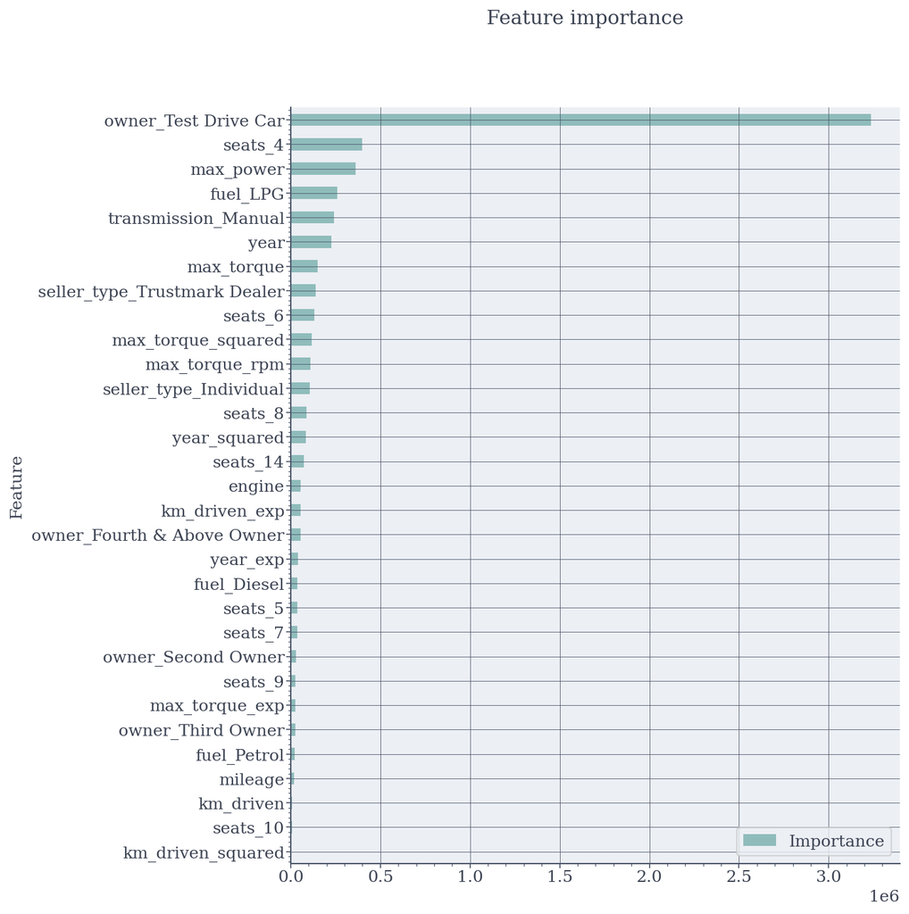

```python
tmp = model_cars_3_2.params.to_frame().iloc[1:]
feature_importance = pd.DataFrame(
    {
        "Feature": tmp.index,
        "Importance": np.abs(tmp[0].values),
    }
)
feature_importance = feature_importance.sort_values("Importance", ascending=True)

fig, ax = plt.subplots(figsize=(8, 10), dpi=150)

feature_importance.plot(
    x="Feature",
    y="Importance",
    kind="barh",
    ax=ax,
)

ax.legend(loc="lower right")

fig.suptitle("Feature importance")
plt.show()
```

Как и в прошлом случае, наиболее важной фитчей оказалось количество владельцев, а именно `owner_Test Drive Car`. Дополнительно сгенерированные фитчи определенно внесли свой вклад в итоговый скор.

# Заключение

В ходе EDA были выдвинуты предположения касаемо местоположения рынка автомобилей и происхождения распределений некоторых параметров (возможно поможет при построении более глубоких моделей), а так же сформирован ряд продуктовых гипотез, которые были проверены далее в блоке статистики.

В ходе регрессионого анализа была построена модель методом МНК со следующими полученными характеристиками:

Итоговый скор: `R2`=0.691.

Список фитчей, вошедших в итоговую модель:

- year (год сборки)
- mileage (расход топлива),
- engine (объем двигателя),
- max_power (кол-во брит. лошадиных сил),
- max_torque (макс. крутящий момент),
- max_torque_rpm (макс. кол-во оборотов в минуту),
- year_exp (exp от год сборки),
- km_driven_exp (exp от пробега),
- max_torque_squared (макс. крутящий момент в квадрате),
- fuel_LPG (тип топлива LPG),
- seller_type_Individual (тип продавца: частник),
- seller_type_Trustmark Dealer (тип продавца: доверенный дилер),
- transmission_Manual (тип КП: ручная),
- owner_Second Owner (после второга владельца),
- owner_Test Drive Car (после тестдрайва),
- seats_4 (4 сиденья),
- seats_6 (6 сидений),
- seats_8 (8 сидений).

Выбор в пользу данных критериев был сделан из полученных значений pvalue указывающих на стат. значимость параметра и из расчитанных значений VIF указывающих на возможную мультилолинеарность (в ходе работы были даны комментарии по данным критериям).